# Advanced Statistical Modelling (ASM) - Final Project

Total production of renewable energy in USA

Odysseas Kyparissis, Pau Comas

2024-01-05

Data is gathered from the [US Energy Information Administration](https://www.eia.gov/totalenergy/data/browser/index.php?tbl=T10.01#/?f=M&start=199001&end=201901&charted=6-7-8-9-14) and it refers to the total production of renewable energy in USA (trillions of BTU-British Thermal Units) from 1990 to 2020.

# Reading and visualizing original timeseries

```r
serie=window(ts(read.table("RenewUSA.dat", header=F),start=1990,freq=12))
serie
```

```
##           Jan      Feb      Mar      Apr      May      Jun      Jul      Aug
## 1990  511.272  508.361  567.935  530.430  525.673  503.363  499.495  497.455
## 1991  569.477  465.116  519.109  492.912  540.589  513.638  499.535  512.229
## 1992  535.605  449.194  482.783  445.954  455.238  497.881  486.977  491.440
## 1993  564.643  477.337  543.313  527.476  537.102  506.688  491.684  502.290
## 1994  546.055  474.597  530.492  515.824  494.547  497.431  538.297  484.333
## 1995  516.505  478.622  550.407  536.526  533.621  560.146  601.277  582.282
## 1996  606.652  571.304  627.925  556.068  594.906  607.617  610.096  594.878
## 1997  629.798  563.285  628.987  603.776  642.247  607.803  611.214  566.984
## 1998  591.525  534.593  585.345  550.085  606.593  538.492  565.999  537.288
## 1999  596.138  533.206  564.564  551.655  610.254  571.951  593.682  547.076
## 2000  505.150  499.959  558.005  568.524  558.724  509.114  526.262  503.686
## 2001  444.970  404.069  455.780  425.366  435.516  454.616  436.066  447.902
## 2002  476.543  428.357  459.464  488.511  527.649  533.572  525.246  469.661
## 2003  470.089  437.335  508.207  509.640  557.612  549.082  524.613  501.519
```

[output cut: 47 more lines]

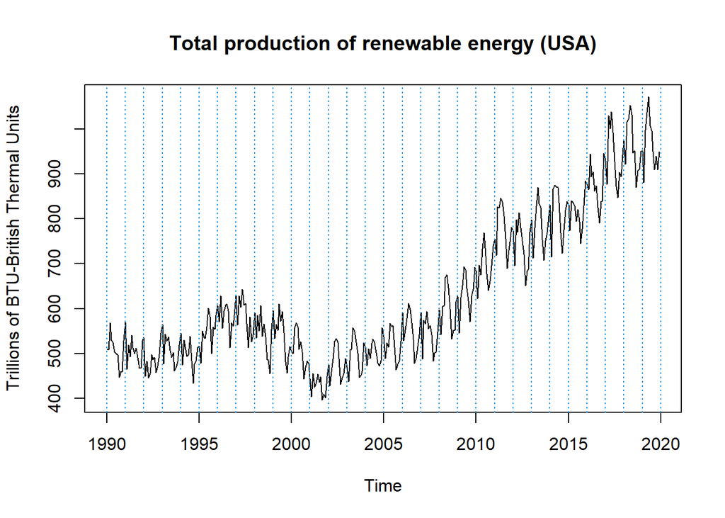

```r
plot(serie, main="Total production of renewable energy (USA)", ylab="Trillions of BTU-British Thermal Units")
abline(v=1990:2020,col=4,lty=3)
```

# Identification

## Determine the needed transformations to make the series stationary.

Justify the transformations carried out using graphical and numerical results.

**Is Variance constant?**

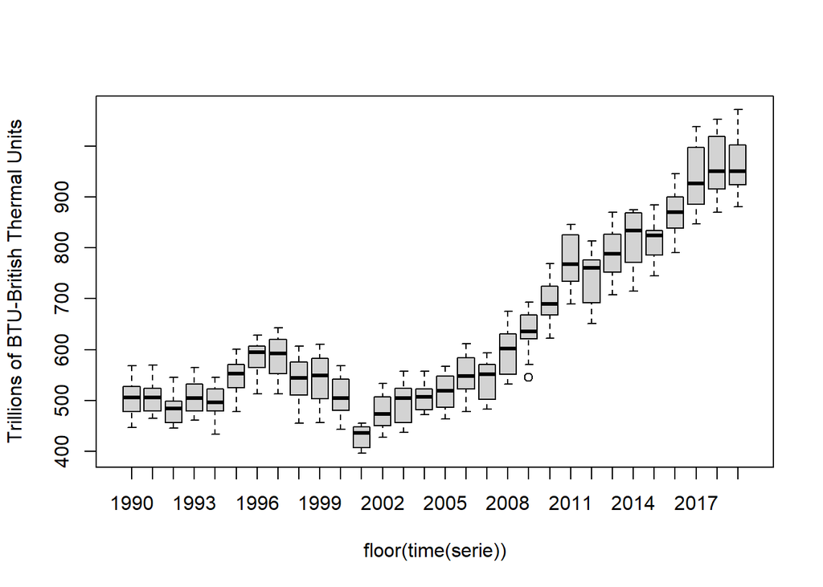

```r
boxplot(serie~floor(time(serie)), ylab="Trillions of BTU-British Thermal Units")
```

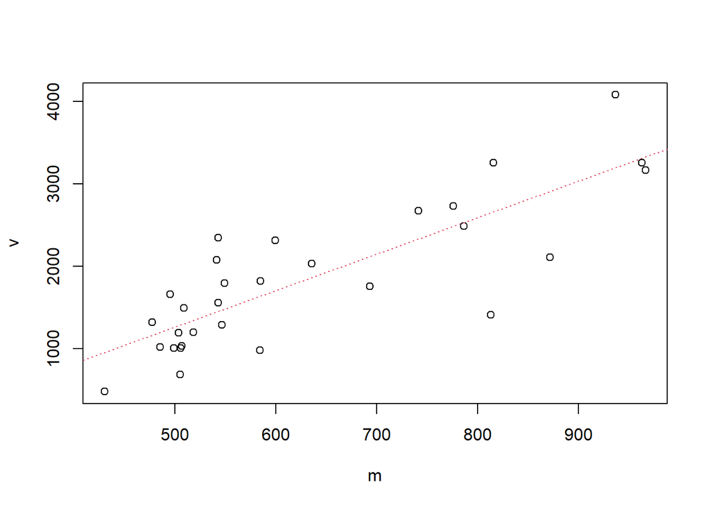

```r
m<-apply(matrix(serie,nrow=12),2,mean)
v<-apply(matrix(serie,nrow=12),2,var)
plot(v~m)
abline(lm(v~m),col=2,lty=3)
```

Although it’s not perfectly clear from the previous two figures, once the mean values get higher the variance get higher as well. For that reason, it is decided to use the logarithmic transformation of the original series.

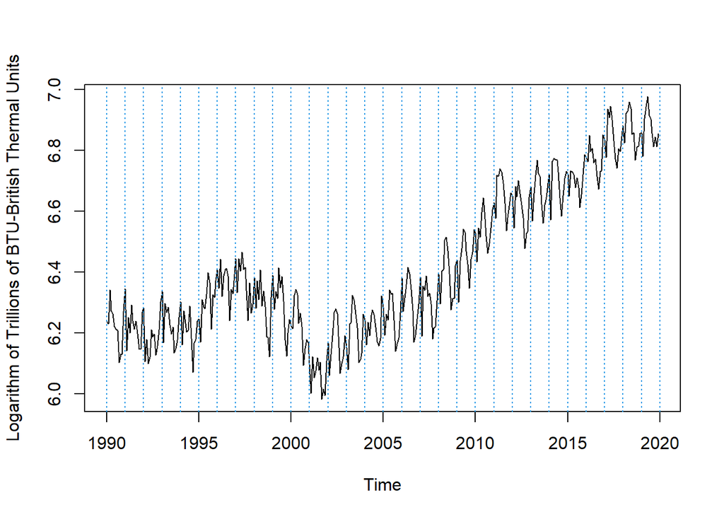

```r
lnserie=log(serie)
plot(lnserie, ylab="Logarithm of Trillions of BTU-British Thermal Units")
abline(v=1990:2020,col=4,lty=3)
abline(h=0)
```

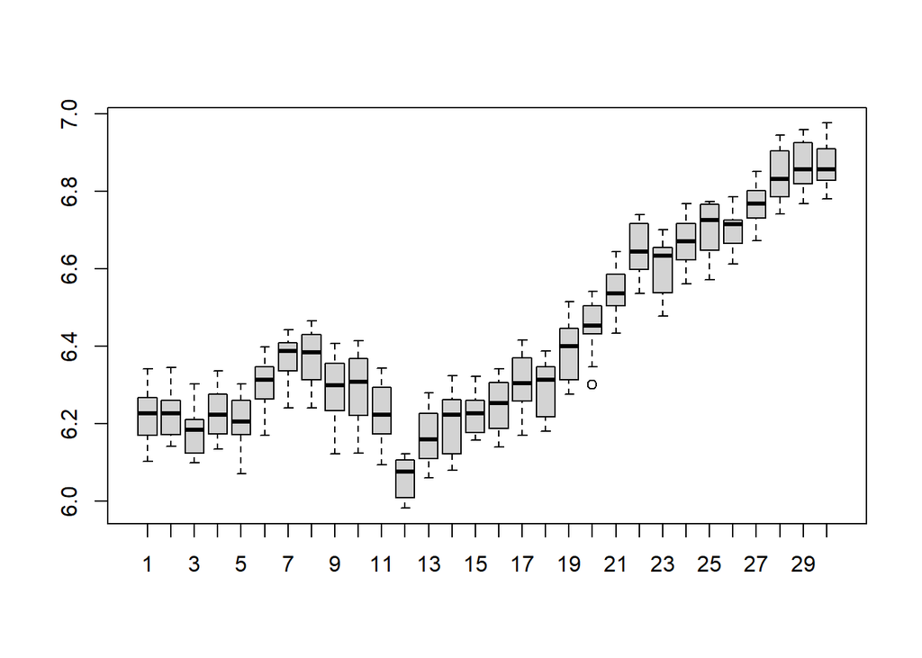

```r
matrixlnserie <- matrix(lnserie,nrow=12)
boxplot(matrixlnserie)
```

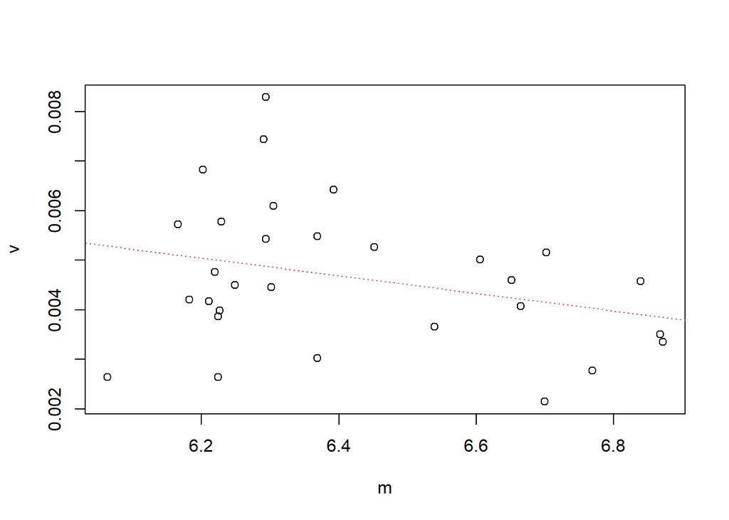

```r
m<-apply(matrixlnserie,2,mean)
v<-apply(matrixlnserie,2,var)
plot(v~m)
abline(lm(v~m),col=2,lty=3)
```

Now, it can be seen that we erased the raise of variability over the mean successfully.

**Is seasonality present?**

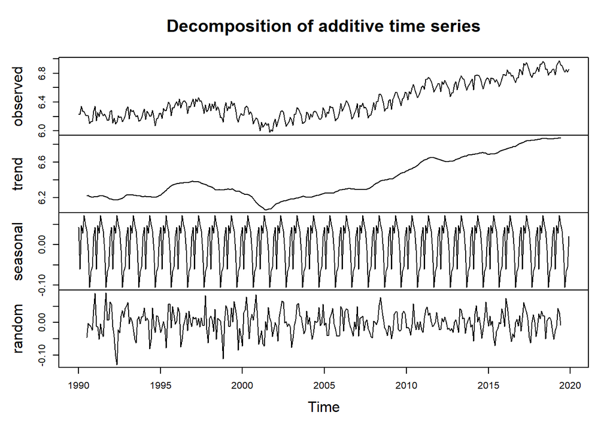

```r
plot(decompose(lnserie))
```

We can clearly see a potential seasonal component, we’ll confirm it nextly. log(Xt) = Linear Trend + Seasonal component + stationary process

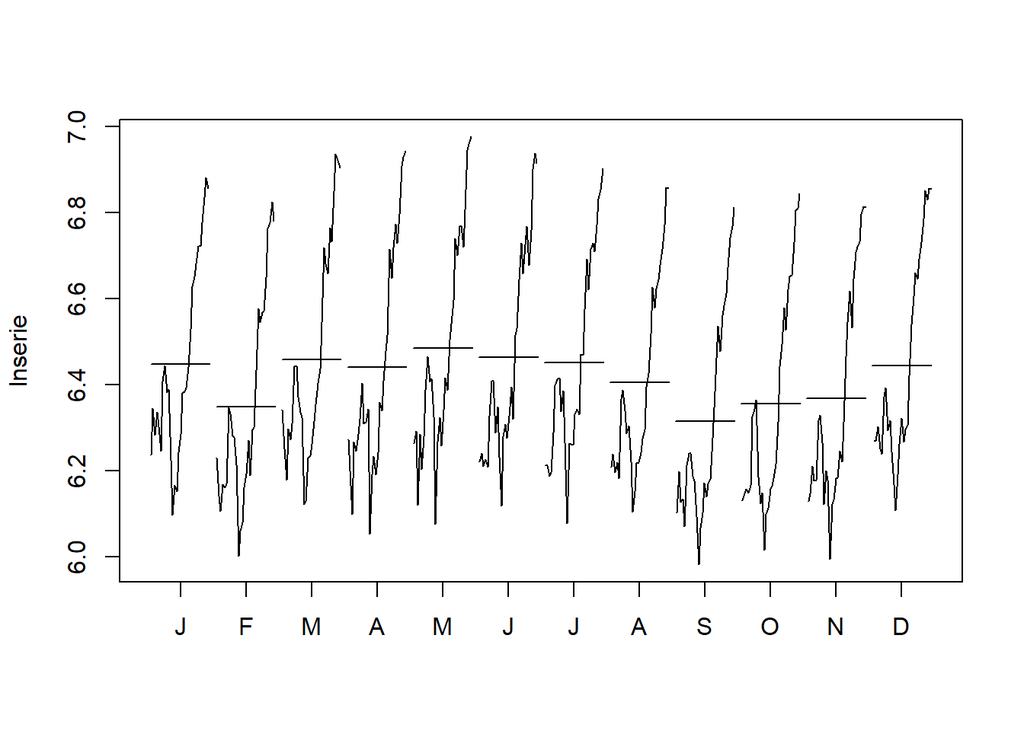

```r
monthplot(lnserie)
```

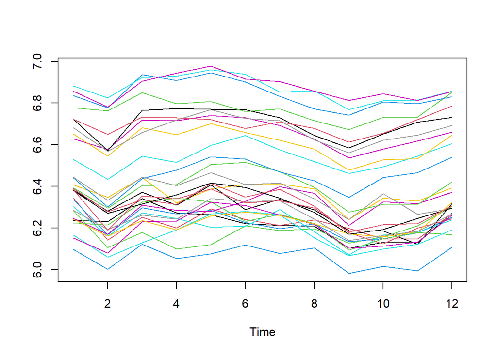

```r
ts.plot(matrix(lnserie,nrow=12),col=1:8)
```

It can be seen that there is an indication about a seasonal pattern, since the mean values of different months fluclutate, and the lines of the timeserie grouped by month show some parallel effects. For this reason a seasonal difference is applied.

- In September we usually have the lowest renewable energy production, and in May the highest.

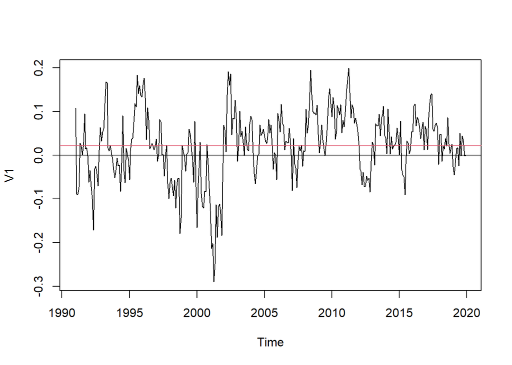

```r
d12lnserie<-diff(lnserie,lag=12)
plot(d12lnserie)
abline(h=0)
abline(h=mean(d12lnserie),col=2)
```

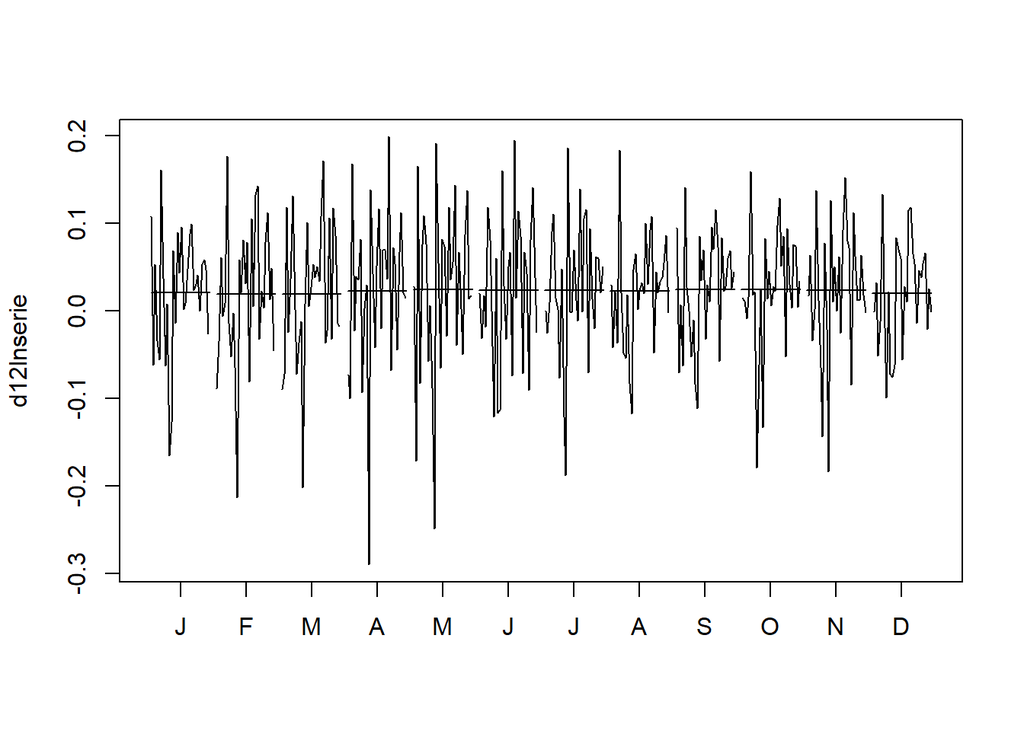

```r
monthplot(d12lnserie)
```

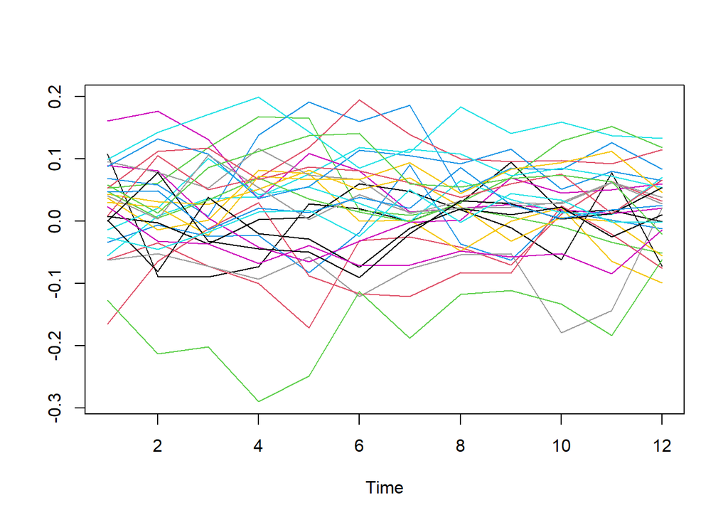

```r
ts.plot(matrix(d12lnserie,nrow=12),col=1:8)
```

Now it is clear that the seasonal pattern is removed.

**Is the mean constant?**

We have to apply one regular difference trying to make the mean constant:

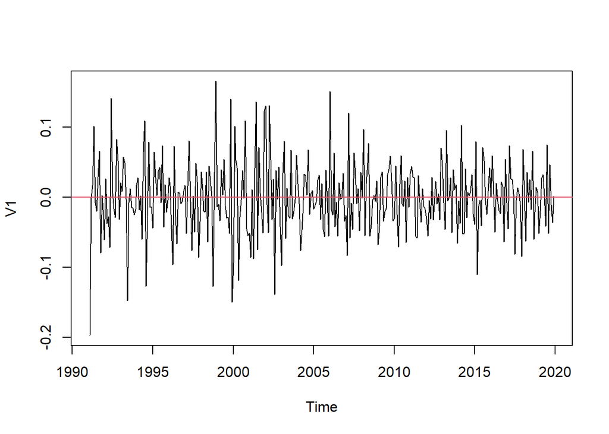

```r
d1d12lnserie=diff(d12lnserie)
plot(d1d12lnserie)
abline(h=0)
abline(h=mean(d1d12lnserie),col=2)
```

Mean seemingly constant equal to zero!!!

**Check for over-differentiation: Take an extra differentiation and compare the variances.**

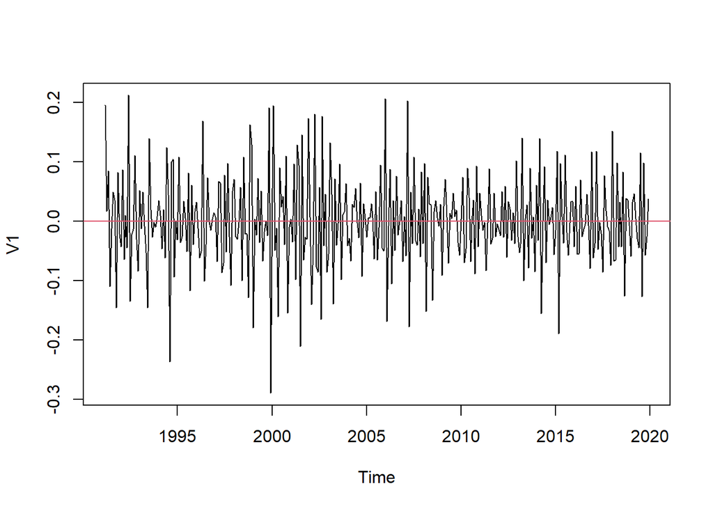

```r
d1d1d12lnserie=diff(d1d12lnserie)
plot(d1d1d12lnserie)
abline(h=0)
abline(h=mean(d1d1d12lnserie),col=2)
```

```r
var(serie)
```

```
##         V1
## V1 26982.9
```

```r
var(lnserie)
```

```
##            V1
## V1 0.05998579
```

```r
var(d12lnserie)
```

```
##            V1
## V1 0.00585664
```

```r
var(d1d12lnserie)
```

```
##             V1
## V1 0.002658468
```

```r
var(d1d1d12lnserie)
```

```
##             V1
## V1 0.006075696
```

`d1d12lnserie` presents the lower variance, so we take it for future steps.

**Is the current series already stationary? Plot the ACF and decide!!**

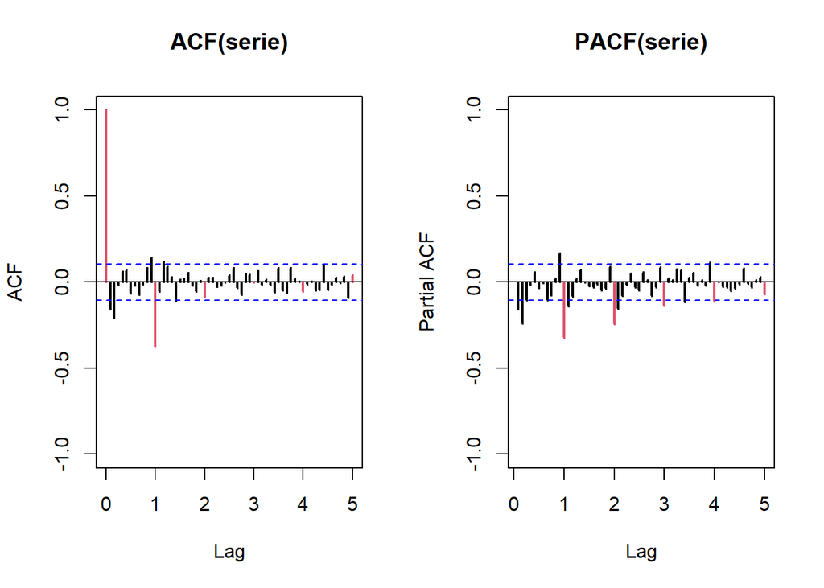

```r
par(mfrow=c(1,2))
acf(d1d12lnserie, ylim=c(-1,1), lag.max=60, col=c(2,rep(1,11)), main ="ACF(serie)", lwd=2)
pacf(d1d12lnserie, ylim=c(-1,1), lag.max=60, col=c(rep(1,11),2), main ="PACF(serie)", lwd=2)
```

- Under Stationarity: ACF falls immediately from 1 to 0
- Under Non-stationary: the ACF declines gradually from 1 to 0 over a prolonged period of time

Thus, we can conclude that `d1d12lnserie` is a stationary series.

Final transformation of the total production of renewable energy (USA) timeseries: $W_t = (1 - B)(1 - B^{12})\log X_t$

## Analyze the ACF and PACF of the stationary series to identify at least two plausible models.

Reason about what features of the correlograms you use to identify these models.

- Seasonal part (red lags): MA(Q=1) or AR(P=4). Since MA(Q=1) has only a single parameter it is preferred.
  - (0,1,1)_12 (MA(Q=1))
  - (4,1,0)_12 (AR(P=4))
- Regular part (black lags): MA(q=2) (considering that black lags around 2nd red lag to be satellites not taking them into account) or AR(p=3) (again considering that black lags around 2nd red lag to be satellites not taking them into account). Since AR(p=3) has 3 parameters we can try with ARMA(1,1) as well.
  - (0,1,2) (MA(q=2))
  - (3,1,0) (AR(p=3))
  - (1,1,1) (ARMA(p=1,q=1))

### Final 6 proposed models:

- (0,1,2)(0,1,1)_12
- (3,1,0)(0,1,1)_12
- (1,1,1)(0,1,1)_12
- (0,1,2)(4,1,0)_12
- (3,1,0)(4,1,0)_12
- (1,1,1)(4,1,0)_12

# Estimation

## Use R to estimate the identified models.

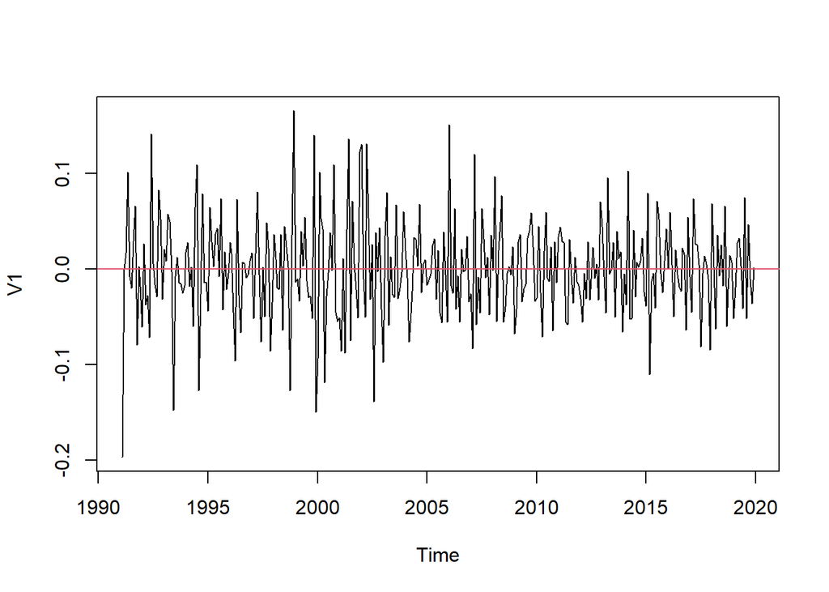

```r
plot(d1d12lnserie)
abline(h=0) # black at 0
abline(h=mean(d1d12lnserie), col=2) # red close to 0
```

```r
(mod0a=arima(d1d12lnserie,order=c(0,0,2),seasonal=list(order=c(0,0,1),period=12)))
```

```
##
## Call:
## arima(x = d1d12lnserie, order = c(0, 0, 2), seasonal = list(order = c(0, 0,
##     1), period = 12))
##
## Coefficients:
##           ma1      ma2     sma1  intercept
##       -0.2494  -0.2274  -0.8348      1e-04
## s.e.   0.0537   0.0560   0.0443      2e-04
##
## sigma^2 estimated as 0.00158:  log likelihood = 619.51,  aic = -1229.01
```

```r
(mod0b=arima(d1d12lnserie,order=c(3,0,0),seasonal=list(order=c(0,0,1),period=12)))
```

```
##
## Call:
## arima(x = d1d12lnserie, order = c(3, 0, 0), seasonal = list(order = c(0, 0,
##     1), period = 12))
##
## Coefficients:
##           ar1      ar2      ar3     sma1  intercept
##       -0.2532  -0.2813  -0.0990  -0.8181      1e-04
## s.e.   0.0550   0.0541   0.0543   0.0449      3e-04
##
## sigma^2 estimated as 0.001585:  log likelihood = 619.52,  aic = -1227.05
```

```r
(mod0c=arima(d1d12lnserie,order=c(1,0,1),seasonal=list(order=c(0,0,1),period=12)))
```

```
##
## Call:
## arima(x = d1d12lnserie, order = c(1, 0, 1), seasonal = list(order = c(0, 0,
##     1), period = 12))
##
## Coefficients:
##          ar1      ma1     sma1  intercept
##       0.4647  -0.7487  -0.8373      1e-04
## s.e.  0.1149   0.0864   0.0448      2e-04
##
## sigma^2 estimated as 0.001597:  log likelihood = 617.51,  aic = -1225.03
```

```r
(mod0d=arima(d1d12lnserie,order=c(0,0,2),seasonal=list(order=c(4,0,0),period=12)))
```

```
##
## Call:
## arima(x = d1d12lnserie, order = c(0, 0, 2), seasonal = list(order = c(4, 0,
##     0), period = 12))
##
## Coefficients:
##           ma1      ma2     sar1     sar2     sar3     sar4  intercept
##       -0.2538  -0.2136  -0.6251  -0.5160  -0.3152  -0.2304      1e-04
## s.e.   0.0548   0.0550   0.0540   0.0627   0.0627   0.0557      5e-04
##
## sigma^2 estimated as 0.001663:  log likelihood = 613.55,  aic = -1211.1
```

```r
(mod0e=arima(d1d12lnserie,order=c(3,0,0),seasonal=list(order=c(4,0,0),period=12)))
```

```
##
## Call:
## arima(x = d1d12lnserie, order = c(3, 0, 0), seasonal = list(order = c(4, 0,
##     0), period = 12))
##
## Coefficients:
##           ar1     ar2      ar3     sar1     sar2     sar3     sar4  intercept
##       -0.2675  -0.295  -0.0971  -0.6289  -0.5235  -0.3130  -0.2226      0e+00
## s.e.   0.0511   0.061   0.0567   0.0545   0.0669   0.0557   0.0798      5e-04
##
## sigma^2 estimated as 0.001653:  log likelihood = 614.61,  aic = -1211.23
```

```r
(mod0f=arima(d1d12lnserie,order=c(1,0,1),seasonal=list(order=c(4,0,0),period=12)))
```

```
##
## Call:
## arima(x = d1d12lnserie, order = c(1, 0, 1), seasonal = list(order = c(4, 0,
##     0), period = 12))
##
## Coefficients:
##          ar1      ma1     sar1     sar2     sar3     sar4  intercept
##       0.4019  -0.6977  -0.6256  -0.5100  -0.3101  -0.2269      1e-04
## s.e.  0.1322   0.1037   0.0542   0.0631   0.0628   0.0558      4e-04
##
## sigma^2 estimated as 0.001687:  log likelihood = 611.11,  aic = -1206.22
```

In all cases, the t-ratio of the intercept is lower than 2, for example:

- `mod0a` and `mod0c`:
  - $$\frac{1e-04}{2e-04} = 0.5 < 2$$

The same is true for the rest of the models following the same idea, meaning that the intercept is not significant. Since the mean was very close to 0 the result was expected. Thus, we can discard the mean, meaning we can move to the training of the model with the original format of the data (after the application of the logarithm).

## Estimating parameters and checking their significance

```r
(mod1a <- arima(lnserie, order=c(0,1,2), seasonal=list(order=c(0,1,1), period=12)))
```

```
##
## Call:
## arima(x = lnserie, order = c(0, 1, 2), seasonal = list(order = c(0, 1, 1), period = 12))
##
## Coefficients:
##           ma1      ma2     sma1
##       -0.2486  -0.2256  -0.8317
## s.e.   0.0537   0.0558   0.0437
##
## sigma^2 estimated as 0.001582:  log likelihood = 619.39,  aic = -1230.79
```

AIC decreased when the intercept was dropped comparing to previous model; thus it was a good decision to drop the intercept.

Let’s check the significance of the parameters of `mod1a`: ma1:
$$\frac{0.2486}{0.0537} = 4.629423 > 2$$
ma2:
$$\frac{0.2256}{0.0558} = 4.043011 > 2$$
sma1:
$$\frac{0.8317}{0.0437} = 19.03204 > 2$$

Thus we can see that all parameters are significant, no need to fix any of them.

Let’s check the significance of the parameters of `mod1b` now:

```r
(mod1b=arima(lnserie,order=c(3,1,0),seasonal=list(order=c(0,1,1),period=12)))
```

```
##
## Call:
## arima(x = lnserie, order = c(3, 1, 0), seasonal = list(order = c(0, 1, 1), period = 12))
##
## Coefficients:
##           ar1      ar2      ar3     sma1
##       -0.2531  -0.2808  -0.0982  -0.8163
## s.e.   0.0550   0.0541   0.0542   0.0445
##
## sigma^2 estimated as 0.001586:  log likelihood = 619.46,  aic = -1228.93
```

ar1:
$$\frac{0.2531}{0.0550} = 4.601818 > 2$$
ar2:
$$\frac{0.2808}{0.0541} = 5.190388 > 2$$
ar3:
$$\frac{0.0982}{0.0542} = 1.811808 < 2$$
sma1:
$$\frac{0.8163}{0.0445} = 18.93409 > 2$$

we can see that `ar3` is not significant, thus we can retrain the model by downgrading the AR part to have `p=2`.

```r
(mod1b_2=arima(lnserie,order=c(2,1,0),seasonal=list(order=c(0,1,1),period=12)))
```

```
##
## Call:
## arima(x = lnserie, order = c(2, 1, 0), seasonal = list(order = c(0, 1, 1), period = 12))
##
## Coefficients:
##           ar1      ar2     sma1
##       -0.2287  -0.2581  -0.8123
## s.e.   0.0535   0.0528   0.0439
##
## sigma^2 estimated as 0.001602:  log likelihood = 617.83,  aic = -1227.66
```

ar1:
$$\frac{0.2287}{0.0535} = 4.274766 > 2$$
ar2:
$$\frac{0.2581}{0.0528} = 4.888258 > 2$$
sma1:
$$\frac{0.8123}{0.0439} = 18.50342 > 2$$

Now all parameters are significant, athough the `AIC` measure got higher, which means that although we could see `ar3` was deemed non-significant, the model with it got a slightly better fit measure and gives us an argument to keep `mod1b`.

Let’s check the significance of the parameters of `mod1c` now:

```r
(mod1c <- arima(lnserie, order=c(1,1,1),seasonal=list(order=c(0,1,1),period=12)))
```

```
##
## Call:
## arima(x = lnserie, order = c(1, 1, 1), seasonal = list(order = c(0, 1, 1), period = 12))
##
## Coefficients:
##          ar1      ma1     sma1
##       0.4597  -0.7434  -0.8331
## s.e.  0.1157   0.0872   0.0440
##
## sigma^2 estimated as 0.0016:  log likelihood = 617.37,  aic = -1226.75
```

ar1:
$$\frac{0.4597}{0.1157} = 3.973207 > 2$$
ma1:
$$\frac{0.7434}{0.0872} = 8.525229 > 2$$
sma1:
$$\frac{0.8331}{0.0440} = 18.93409 > 2$$

again all of them are significant.

Let’s check the significance of the parameters of `mod1d` now:

```r
(mod1d=arima(lnserie,order=c(0,1,2),seasonal=list(order=c(4,1,0),period=12)))
```

```
##
## Call:
## arima(x = lnserie, order = c(0, 1, 2), seasonal = list(order = c(4, 1, 0), period = 12))
##
## Coefficients:
##           ma1      ma2    sar1     sar2     sar3     sar4
##       -0.2537  -0.2135  -0.625  -0.5160  -0.3151  -0.2303
## s.e.   0.0548   0.0550   0.054   0.0627   0.0627   0.0557
##
## sigma^2 estimated as 0.001663:  log likelihood = 613.54,  aic = -1213.08
```

ma1:
$$\frac{0.2537}{0.0548} = 4.629562 > 2$$
ma2:
$$\frac{0.2135}{0.0550} = 3.881818 > 2$$
sar1:
$$\frac{0.625}{0.054} = 11.57407 > 2$$
sar2:
$$\frac{0.5160}{0.0627} = 8.229665 > 2$$
sar3:
$$\frac{0.3151}{0.0627} = 5.025518 > 2$$
sar4:
$$\frac{0.2303}{0.0557} = 4.13465 > 2$$

For `mod1e`:

```r
(mod1e=arima(lnserie,order=c(3,1,0),seasonal=list(order=c(4,1,0),period=12)))
```

```
##
## Call:
## arima(x = lnserie, order = c(3, 1, 0), seasonal = list(order = c(4, 1, 0), period = 12))
##
## Coefficients:
##           ar1      ar2      ar3     sar1     sar2     sar3     sar4
##       -0.2679  -0.2949  -0.0972  -0.6291  -0.5229  -0.3126  -0.2222
## s.e.   0.0615   0.0786   0.0602   0.0632   0.0888   0.0751   0.0848
##
## sigma^2 estimated as 0.001653:  log likelihood = 614.6,  aic = -1213.21
```

ar1:
$$\frac{0.2679}{0.0615} = 4.356098 > 2$$
ar2:
$$\frac{0.2949}{0.0786} = 3.751908 > 2$$
ar3:
$$\frac{0.0972}{0.0602} = 1.614618 < 2$$
sar1:
$$\frac{0.6291}{0.0632} = 9.954114 > 2$$
sar2:
$$\frac{0.5229}{0.0888} = 5.888514 > 2$$
sar3:
$$\frac{0.3126}{0.0751} = 4.16245 > 2$$
sar4:
$$\frac{0.2222}{0.0848} = 2.620283 > 2$$

Again, it can be seen that `ar3` is an insignificant parameter, for that reason we will change it to an `AR` with `p=2`.

```r
(mod1e_2=arima(lnserie,order=c(2,1,0),seasonal=list(order=c(4,1,0),period=12)))
```

```
##
## Call:
## arima(x = lnserie, order = c(2, 1, 0), seasonal = list(order = c(4, 1, 0), period = 12))
##
## Coefficients:
##           ar1      ar2     sar1     sar2     sar3     sar4
##       -0.2417  -0.2706  -0.6342  -0.5209  -0.3149  -0.2247
## s.e.   0.0538   0.0530   0.0544   0.0632   0.0631   0.0558
##
## sigma^2 estimated as 0.001668:  log likelihood = 613.02,  aic = -1212.05
```

ar1:
$$\frac{0.2417}{0.0538} = 4.492565 > 2$$
ar2:
$$\frac{0.2706}{0.0530} = 5.10566 > 2$$
sar1:
$$\frac{0.6342}{0.0544} = 11.65809 > 2$$
sar2:
$$\frac{0.5209}{0.0632} = 8.242089 > 2$$
sar3:
$$\frac{0.3149}{0.0631} = 4.990491 > 2$$
sar4:
$$\frac{0.2247}{0.0558} = 4.026882 > 2$$

For `mod1f`:

```r
(mod1f=arima(lnserie,order=c(1,1,1),seasonal=list(order=c(4,1,0),period=12)))
```

```
##
## Call:
## arima(x = lnserie, order = c(1, 1, 1), seasonal = list(order = c(4, 1, 0), period = 12))
##
## Coefficients:
##          ar1      ma1     sar1    sar2     sar3     sar4
##       0.4016  -0.6974  -0.6255  -0.510  -0.3100  -0.2269
## s.e.  0.1315   0.1033   0.0542   0.063   0.0628   0.0558
##
## sigma^2 estimated as 0.001687:  log likelihood = 611.1,  aic = -1208.2
```

Again:

ar1:
$$\frac{0.4016}{0.1315} = 3.053992 > 2$$
ma1:
$$\frac{0.6974}{0.1033} = 6.75121 > 2$$
sar1:
$$\frac{0.6255}{0.0542} = 11.54059 > 2$$
sar2:
$$\frac{0.5100}{0.0630} = 8.095238 > 2$$
sar3:
$$\frac{0.3100}{0.0628} = 4.936306 > 2$$
sar4:
$$\frac{0.2269}{0.0558} = 4.066308 > 2$$

To conclude, we can see that between all models the lowest AIC values is $AIC = -1230.79$ for `mod1a`, followed by `mod1b` with $AIC = -1228.93$. For this reason it is decided to continue the analysis with `mod1a` and `mod1b`.

# Validation

## mod1a

### Residual Plot

In the following plot we need to see a constant variance of the residuals. Between the blue lines of -2, +2 stds (for each thousand only 2 can be outside) I need to find the 95% of the observations. Or 97.5% between -3, +3 stds (for each thousand only 3 can be outside).

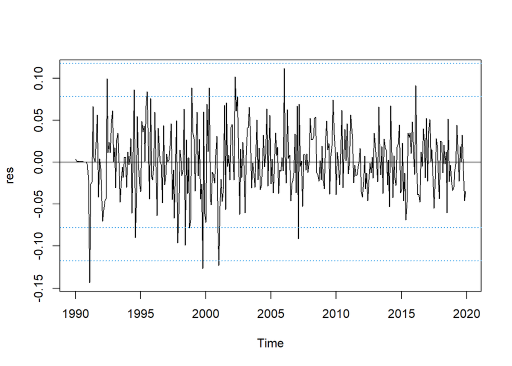

```r
res = resid(mod1a)
plot(res, type='l')
abline(h=0)
abline(h=c(-3,-2,2,3)*sd(res), lty=3, col=4)
```

We can see that there are several cases where the data lay outside the intervals of standard deviations violating the afore-mentioned rule. Thus, either `clusters of volatility` exist, meaning that the variance increases (or in general changes a lot) in specific periods, or `outliers` are present which need to be treated. Outlier treatment is performed lately.

### Estimation of the Dispertion

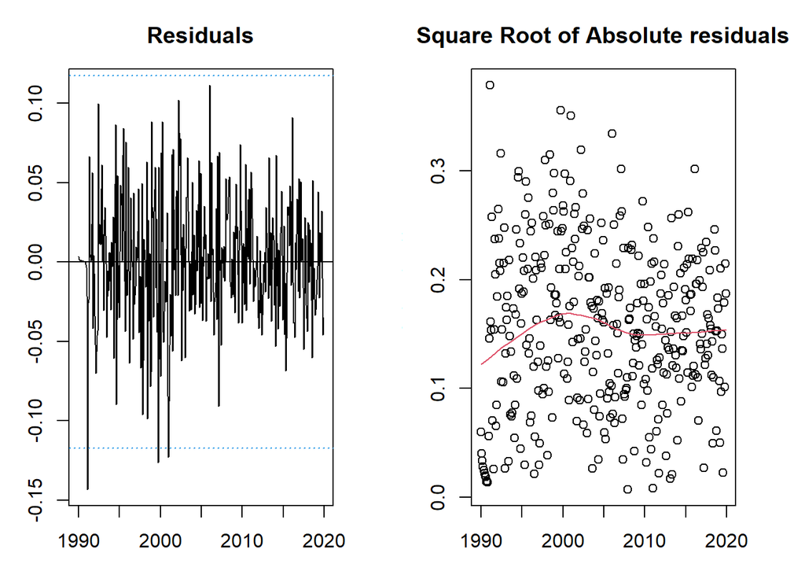

```r
par(mfrow=c(1,2),mar=c(3,3,3,3))
#Residuals plot
plot(res,main="Residuals")
abline(h=0)
abline(h=c(-3*sd(res),3*sd(res)),lty=3,col=4)
#Square Root of absolute values of residuals (Homocedasticity)
scatter.smooth(sqrt(abs(res)),main="Square Root of Absolute residuals",
lpars=list(col=2))
```

We can see in both graphical representations generated before, that the variance of the residuals is not constant. The red line shows that there is bigger variance during a specific period.

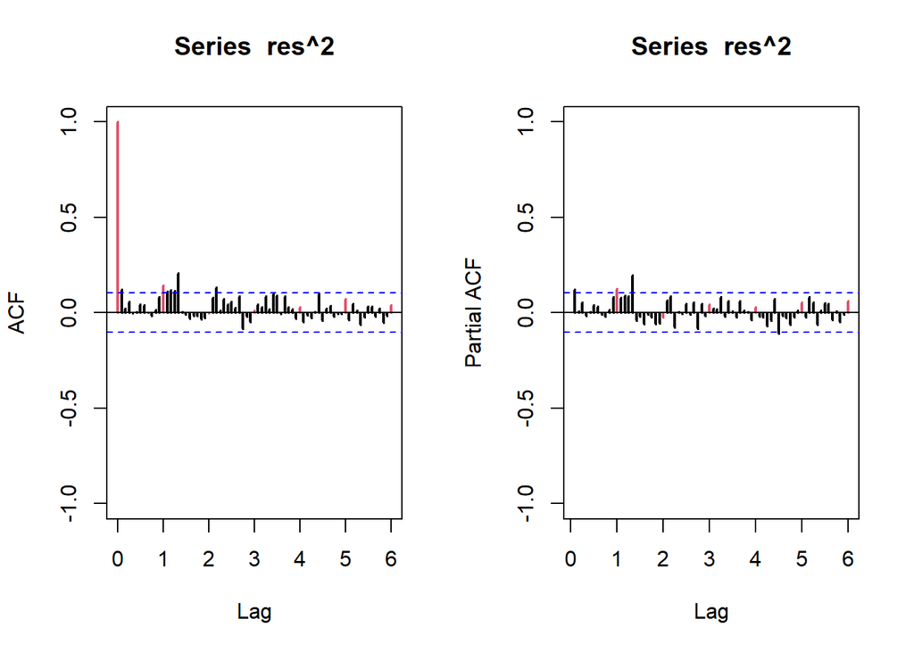

```r
par(mfrow=c(1,2))
acf(res^2, ylim=c(-1,1), lag.max = 72, col=c(2,rep(1,11)),lwd=2)
pacf(res^2, ylim=c(-1,1), lag.max = 72, col=c(rep(1,11),2), lwd=2)
```

```r
par(mfrow=c(1,1))
```

We need all the lags to be not significant, meaning that there is no correlation between the residuals with themselves. When we find significant lags here, implies that there is volatility. It means that we have a time series that at some point the variability is small and at the same level in a different time the variability is high.

When heteroscedasticity is present, there are 2 things that might lead to this result, or we have outliers or volatility. If the points lying outside the borders are not so much most probably we are having outliers, otherwise we might have volatility.

### Normality test

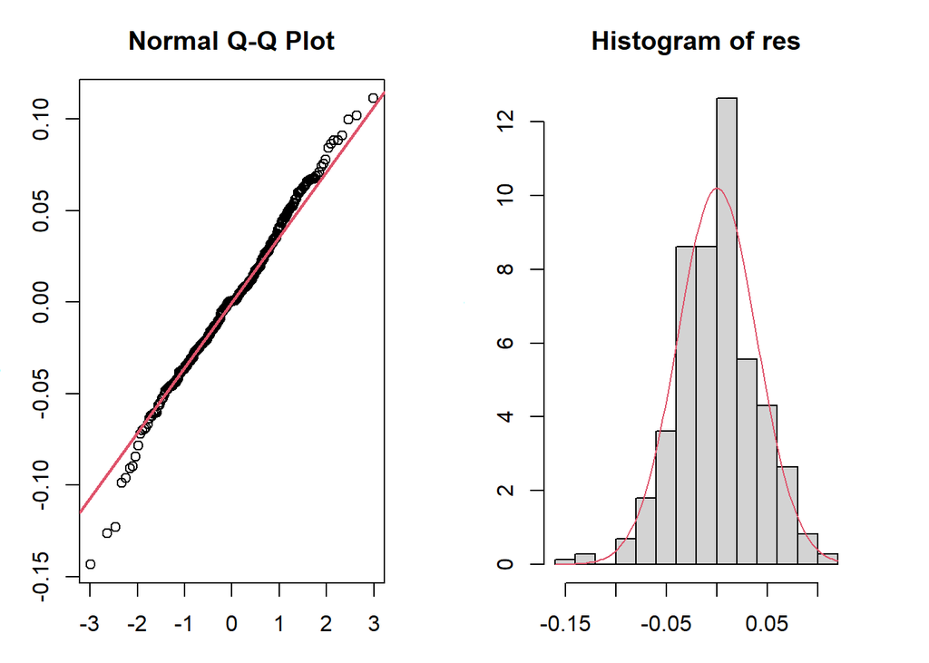

```r
par(mfrow=c(1,2),mar=c(3,3,3,3))
#Normal plot of residuals
qqnorm(res)
qqline(res,col=2,lwd=2)
##Histogram of residuals with normal curve
hist(res,breaks=10,freq=F)
curve(dnorm(x,mean=mean(res),sd=sd(res)),col=2,add=T)
```

```r
##Shapiro-Wilks Normality test
print(shapiro.test(res))
```

```
##
##  Shapiro-Wilk normality test
##
## data:  res
## W = 0.99186, p-value = 0.04585
```

In the Q-Q plot we need to find the residuals lying near the red line. If we find curvature in the left plot, it represents asymmetry of the residuals. For example, in economic data we could find in the start and the end big differences from the red lines. If those points are a lot it might indicate volatility (HEAVY TAILS) (Excess of kurtosis) (this means that the kurtosis, 3rd moment, is greater than 3, that the probability of outliers is greater than the Gaussian), if they are not a lot, they could represent outliers.

In this case, according to the Q-Q plot and the histogram, we believe normality could be reasonably acceptable, but with the presence of outliers. We base this in the countable number of points that diverge at the ends of the red line in the Q-Q plot. Because of this, the Shapiro-Wilk test rejects normality by a small margin, which we credit to the outliers effect.

### Total Validation

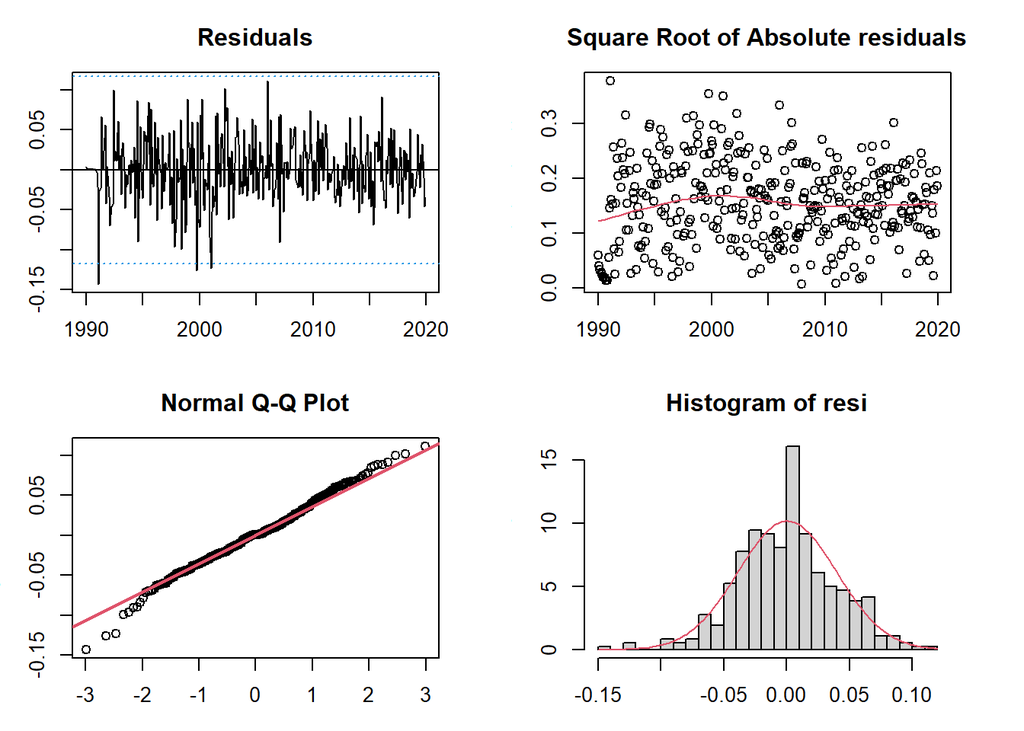

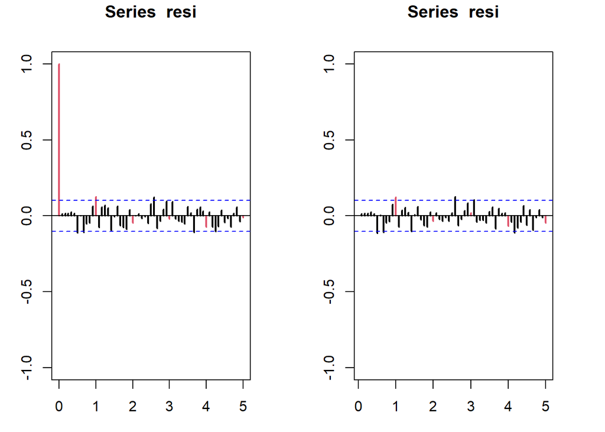

```
##
## --------------------------------------------------------------------
##
## Call:
## arima(x = lnserie, order = c(0, 1, 2), seasonal = list(order = c(0, 1, 1), period = 12))
##
## Coefficients:
##           ma1      ma2     sma1
##       -0.2486  -0.2256  -0.8317
## s.e.   0.0537   0.0558   0.0437
##
## sigma^2 estimated as 0.001582:  log likelihood = 619.39,  aic = -1230.79
##
## Modul of AR Characteristic polynomial Roots:
##
## Modul of MA Characteristic polynomial Roots:  1.015479 1.015479 1.015479 1.015479 1.015479 1.015479 1.015479 1.015479 1.015479 1.015479 1.015479 1.015479 1.625291 2.727236
```

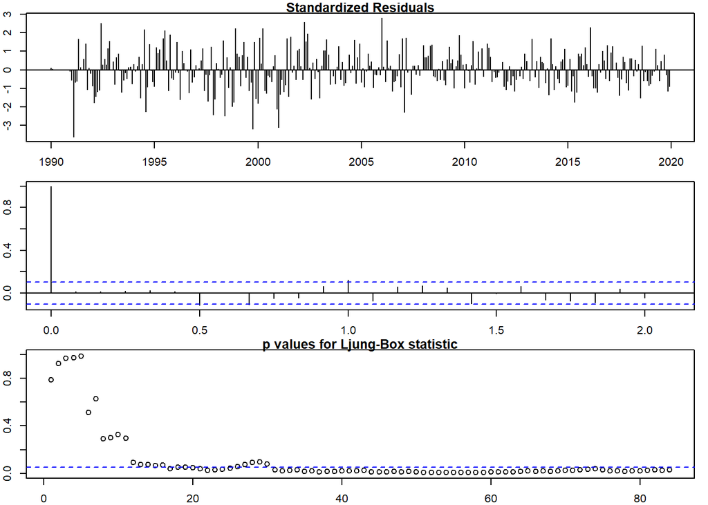

```
##
## Psi-weights (MA(inf))
##
## --------------------
##      psi 1      psi 2      psi 3      psi 4      psi 5      psi 6      psi 7
## -0.2486028 -0.2256036  0.0000000  0.0000000  0.0000000  0.0000000  0.0000000
##      psi 8      psi 9     psi 10     psi 11     psi 12     psi 13     psi 14
##  0.0000000  0.0000000  0.0000000  0.0000000 -0.8316618  0.2067534  0.1876259
##     psi 15     psi 16     psi 17     psi 18     psi 19     psi 20     psi 21
##  0.0000000  0.0000000  0.0000000  0.0000000  0.0000000  0.0000000  0.0000000
##     psi 22     psi 23     psi 24
##  0.0000000  0.0000000  0.0000000
##
## Pi-weights (AR(inf))
##
## --------------------
##         pi 1         pi 2         pi 3         pi 4         pi 5         pi 6
## -0.248602761 -0.287406955 -0.127535846 -0.096545814 -0.052774105 -0.034900873
##         pi 7         pi 8         pi 9        pi 10        pi 11        pi 12
## -0.020582483 -0.012990626 -0.007872988 -0.004887979 -0.002991340 -0.833508153
##        pi 13        pi 14        pi 15        pi 16        pi 17        pi 18
## -0.207887286 -0.239723812 -0.106496126 -0.080557791 -0.044052801 -0.029125778
##        pi 19        pi 20        pi 21        pi 22        pi 23        pi 24
## -0.017179220 -0.010841683 -0.006570967 -0.004079483 -0.002496605 -0.693202279
##
## Descriptive Statistics for the Residuals
##
## ----------------------------------------
```

```
##                   resi
## nobs        360.000000
## NAs           0.000000
## Minimum      -0.143429
## Maximum       0.111448
## 1. Quartile  -0.024140
## 3. Quartile   0.023843
## Mean          0.000427
## Median        0.000480
## Sum           0.153768
## SE Mean       0.002062
## LCL Mean     -0.003627
## UCL Mean      0.004482
## Variance      0.001530
## Stdev         0.039116
## Skewness     -0.097524
## Kurtosis      0.573506
##
## Normality Tests
##
## --------------------
##
##  Shapiro-Wilk normality test
##
## data:  resi
## W = 0.99186, p-value = 0.04585
##
##
##  Anderson-Darling normality test
##
## data:  resi
## A = 0.74087, p-value = 0.05315
```

```
##
##  Jarque Bera Test
##
## data:  resi
## X-squared = 5.858, df = 2, p-value = 0.05345
##
##
## Homoscedasticity Test
##
## --------------------
```

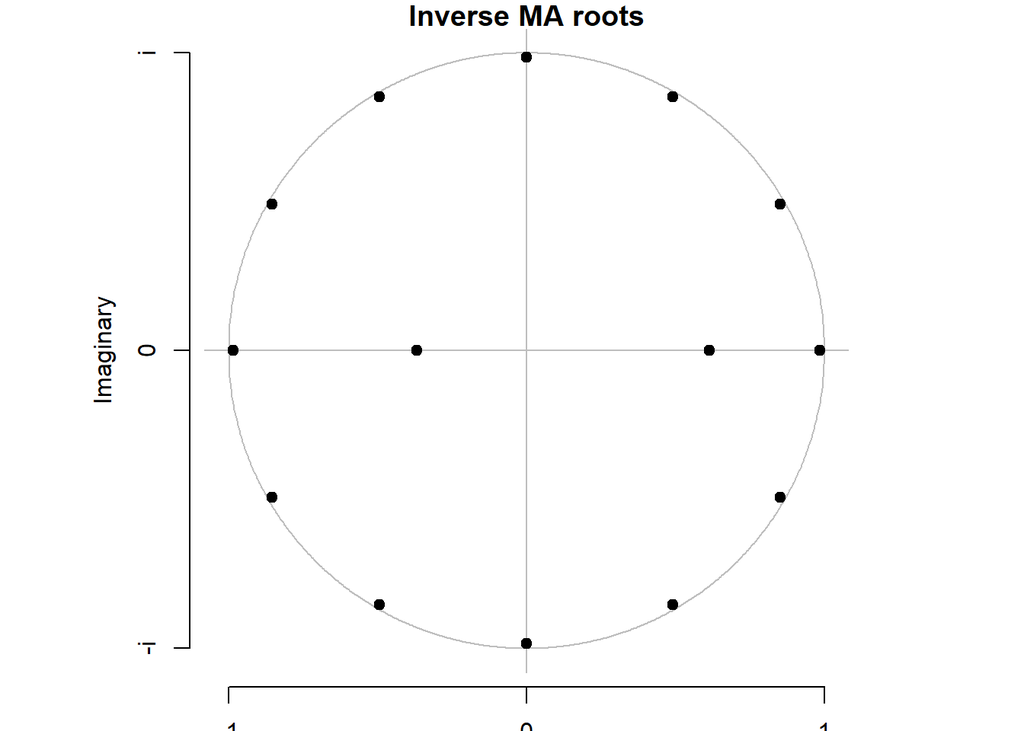

```
##
##  studentized Breusch-Pagan test
##
## data:  resi ~ I(obs - resi)
## BP = 8.4745, df = 1, p-value = 0.003602
##
##
## Independence Tests
##
## --------------------
##
##  Durbin-Watson test
##
## data:  resi ~ I(1:length(resi))
## DW = 1.9699, p-value = 0.3672
## alternative hypothesis: true autocorrelation is greater than 0
##
##
## Ljung-Box test
##      lag.df   statistic    p.value
## [1,]      1  0.07375542 0.78594537
## [2,]      2  0.15636122 0.92479739
## [3,]      3  0.26432365 0.96659237
## [4,]      4  0.52375770 0.97114733
## [5,]     12 18.78933838 0.09374074
## [6,]     24 38.20929376 0.03299880
## [7,]     36 55.32121818 0.02073127
## [8,]     48 72.26346535 0.01333233
```

```r
validation(mod1a)
```

With the initial analyses, we have rejected homoscedasticity and reasonably accepted normality. Now we evaluate invertibility, causality and independence with the remaining analyses:

**Invertibility and causality**

If all the complex roots of the characteristic polynomial of the `MA` part lie outside the unit circle the model is invertible. Here, we deal with the inverse of the roots, so we want all the points inside instead of outside, which is true. Thus, the model can be represented as a convergent $AR(\infty)$ expression with $\pi$-weights (useful for estimating point predictions). For causality, we know that all MA(q) models are causal, which is the case. Thus, the model can be represented as a convergent $MA(\infty)$ expression with $\psi$-weights(useful for estimating the variance of estimated point predictions).

**Residuals independence**

As for `ljung box` tests, we see several rejections of white noise for residuals, since there are p values lower than $0,05$. The null hypothesis for the Ljung-Box test is that the auto-correlations of a time series are zero for all lags up to a certain specified lag $k$. In this specific case, from lag 22 to beyond, most of the lags fail the test for no-autocorrelation, so it can’t be deemed as white noise behavior.

## mod1b

In this case, we won’t go step by step and will perform the whole validation with the `validation` function graphs and tests at once.

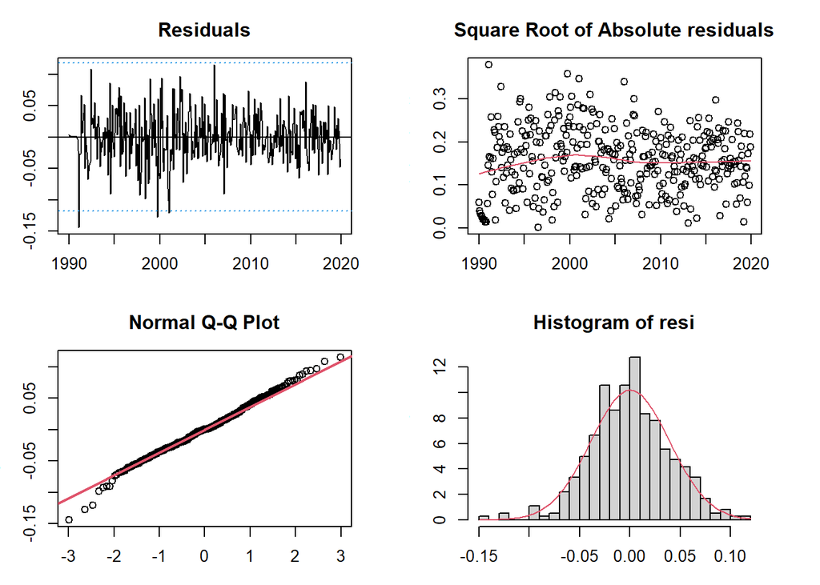

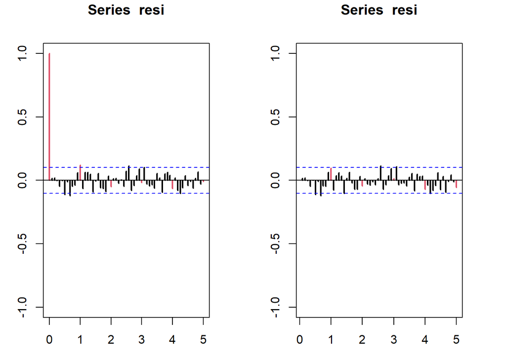

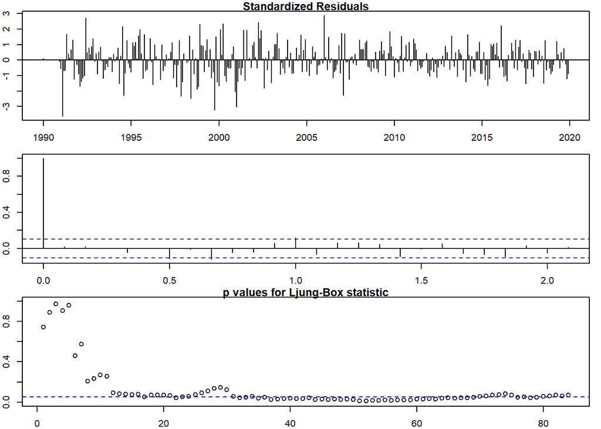

```
##
## --------------------------------------------------------------------
##
## Call:
## arima(x = lnserie, order = c(3, 1, 0), seasonal = list(order = c(0, 1, 1), period = 12))
##
## Coefficients:
##           ar1      ar2      ar3     sma1
##       -0.2531  -0.2808  -0.0982  -0.8163
## s.e.   0.0550   0.0541   0.0542   0.0445
##
## sigma^2 estimated as 0.001586:  log likelihood = 619.46,  aic = -1228.93
##
## Modul of AR Characteristic polynomial Roots:  1.814813 1.814813 3.090462
##
## Modul of MA Characteristic polynomial Roots:  1.017058 1.017058 1.017058 1.017058 1.017058 1.017058 1.017058 1.017058 1.017058 1.017058 1.017058 1.017058
```

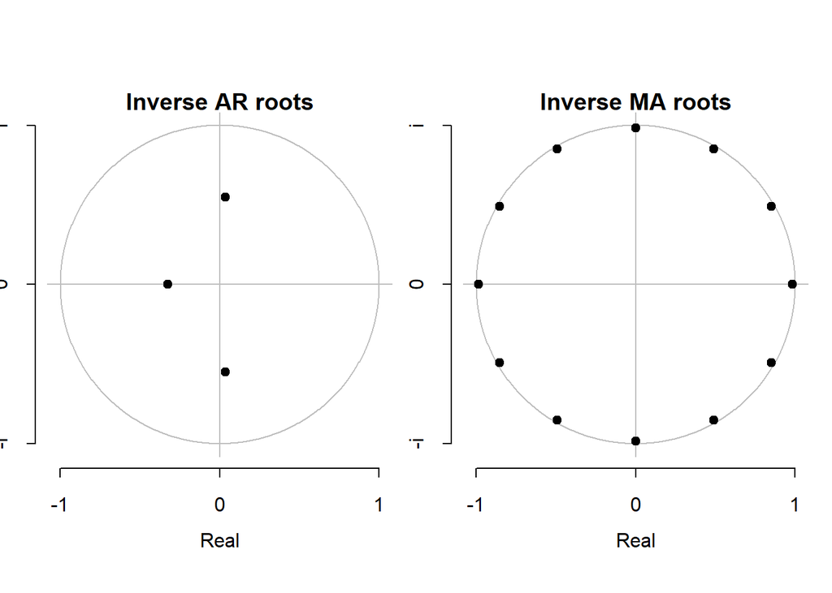

```
##
## Psi-weights (MA(inf))
##
## --------------------
##         psi 1         psi 2         psi 3         psi 4         psi 5
## -2.530637e-01 -2.167666e-01  2.767254e-02  7.872923e-02 -6.397830e-03
##         psi 6         psi 7         psi 8         psi 9        psi 10
## -2.320743e-02 -6.527402e-05  7.161906e-03  4.859369e-04 -2.127680e-03
##        psi 11        psi 12        psi 13        psi 14        psi 15
## -3.016415e-04 -8.156756e-01  2.067116e-01  1.767665e-01 -2.264298e-02
##        psi 16        psi 17        psi 18        psi 19        psi 20
## -6.421581e-02  5.242499e-03  1.893019e-02  4.623592e-05 -5.842499e-03
##        psi 21        psi 22        psi 23        psi 24
## -3.942651e-04  1.735851e-03  2.454310e-04 -5.108156e-04
##
## Pi-weights (AR(inf))
##
## --------------------
##        pi 1        pi 2        pi 3        pi 4        pi 5        pi 6
## -0.25306371 -0.28080786 -0.09824551  0.00000000  0.00000000  0.00000000
##        pi 7        pi 8        pi 9       pi 10       pi 11       pi 12
##  0.00000000  0.00000000  0.00000000  0.00000000  0.00000000 -0.81630167
##       pi 13       pi 14       pi 15       pi 16       pi 17       pi 18
## -0.20657633 -0.22922393 -0.08019797  0.00000000  0.00000000  0.00000000
##       pi 19       pi 20       pi 21       pi 22       pi 23       pi 24
##  0.00000000  0.00000000  0.00000000  0.00000000  0.00000000 -0.66634841
##
## Descriptive Statistics for the Residuals
##
## ----------------------------------------
##                   resi
## nobs        360.000000
## NAs           0.000000
## Minimum      -0.144168
## Maximum       0.115238
## 1. Quartile  -0.025162
## 3. Quartile   0.023822
## Mean          0.000211
## Median        0.000202
## Sum           0.075788
```

[output cut: 46 more lines]

```
## data:  resi ~ I(1:length(resi))
## DW = 1.9639, p-value = 0.3459
## alternative hypothesis: true autocorrelation is greater than 0
##
##
## Ljung-Box test
##      lag.df  statistic    p.value
## [1,]      1  0.1062815 0.74441803
## [2,]      2  0.2329066 0.89007165
## [3,]      3  0.2340508 0.97191369
## [4,]      4  1.0122580 0.90793161
## [5,]     12 18.8963384 0.09106100
## [6,]     24 35.8879283 0.05627654
## [7,]     36 51.4048787 0.04620721
## [8,]     48 68.7723429 0.02619937
```

```r
validation(mod1b)
```

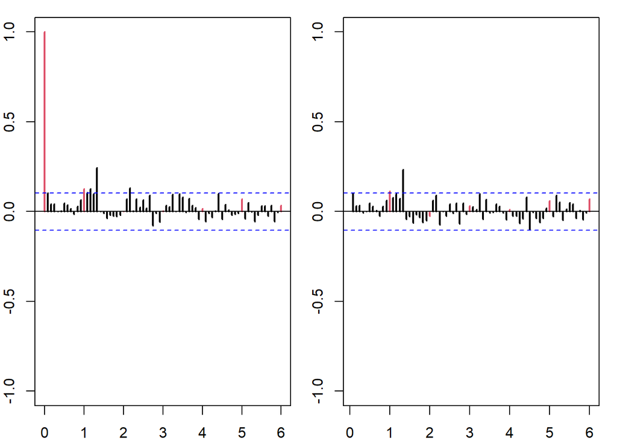

```r
res2 = resid(mod1b)
par(mfrow=c(1,2))
acf(res2^2, ylim=c(-1,1), lag.max = 72, col=c(2,rep(1,11)),lwd=2)
pacf(res2^2, ylim=c(-1,1), lag.max = 72, col=c(rep(1,11),2), lwd=2)
```

```r
par(mfrow=c(1,1))
```

**Normality and variance**

We have very similar behavior as in `mod1a`, with a possible normality affected by outliers, according to the Q-Q plot and the histogram. Nonetheless, for this model, the Shapiro-Wilk test acknowledges normality, as opposite to the other model. For variance, outliers could also be making the Breusch-Pagan test to reject homoscedasticity and the square root of absolute residuals shows a bit of variance variability at the first half of the data.

**Invertibility and causality**

Since –> Modul of AR Characteristic polynomial Roots: 1.814813 1.814813 3.090462 and –> Modul of MA Characteristic polynomial Roots: 1.017058 1.017058 1.017058 1.017058 1.017058 1.017058 1.017058 1.017058 1.017058 1.017058 1.017058 1.017058

We can say the model is invertible and causal. Thus, the model can be represented as a convergent $AR(\infty)$ expression with $\pi$-weights (useful for estimating point predictions) In addition, the model can be represented as a convergent $MA(\infty)$ expression with $\psi$-weights(useful for estimating the variance of estimated point predictions).

**Residuals independence**

As for `ljung box` tests, we see several rejections of white noise for residuals, since there are p values lower than $0,05$. The null hypothesis for the Ljung-Box test is that the auto-correlations of a time series are zero for all lags up to a certain specified lag $k$. In this specific case, from lag 30 to beyond, most of the lags fail the test for no-autocorrelation, so it can’t be deemed as white noise behavior.

# Predictions

Both models showcase similar behavior affected potentially by outliers. Nonetheless, slightly more favorable assessments obtained with `mod1b` for normality and Ljung-Box test, and very similar `AIC` goodness of fit and simplicity indicator is the reason why we choose `mod1b` for the prediction section.

We use proposed `mod1b` $ARIMA(3,1,0)(0,1,1)_{12}$ model for predictions

## Stability of mod1b

```r
# capability of prediction and calculation of the measures
# position of last observation for train dataset is 12 2018. test from there until 2019 12.
ultim=c(2018,12)
pdq=c(3,1,0)
PDQ=c(0,1,1)

serie2=window(serie, end=ultim)
lnserie2=log(serie2)
serie1=window(serie, end=ultim+c(1,0))
lnserie1=log(serie1)

(modA=arima(lnserie1,order=pdq,seasonal=list(order=PDQ,period=12)))
```

```
##
## Call:
## arima(x = lnserie1, order = pdq, seasonal = list(order = PDQ, period = 12))
##
## Coefficients:
##           ar1      ar2      ar3     sma1
##       -0.2531  -0.2808  -0.0982  -0.8163
## s.e.   0.0550   0.0541   0.0542   0.0445
##
## sigma^2 estimated as 0.001586:  log likelihood = 619.46,  aic = -1228.93
```

```r
#we want to check if model with train dataset is very similar to model with whole set. this is to check if test set is stable.
# we check magnitude, t ratio and signs.
# if they were not similar, model is not stable, and means i cannot calculate with metrics the model capability, structural change in test period.
```

```r
(modB=arima(lnserie2,order=pdq,seasonal=list(order=PDQ,period=12)))
```

```
##
## Call:
## arima(x = lnserie2, order = pdq, seasonal = list(order = PDQ, period = 12))
##
## Coefficients:
##           ar1      ar2     ar3     sma1
##       -0.2591  -0.2821  -0.097  -0.8167
## s.e.   0.0560   0.0551   0.055   0.0459
##
## sigma^2 estimated as 0.001616:  log likelihood = 594.62,  aic = -1179.23
```

Clearly, stability of the model is fulfilled. We observe similar results in terms of significance, sign and magnitude. In practice, this means that the correlation structure has not changed in the last year, and that the use of the complete series for making predictions is reliable. Test set is stable.

## Forecasting

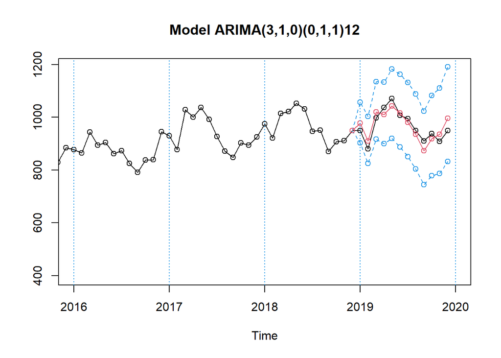

```r
pred=predict(modB,n.ahead=12)
pr<-ts(c(tail(lnserie2,1),pred$pred),start=ultim,freq=12)
se<-ts(c(0,pred$se),start=ultim,freq=12)

#Intervals
tl<-ts(exp(pr-1.96*se),start=ultim,freq=12)
tu<-ts(exp(pr+1.96*se),start=ultim,freq=12)
pr<-ts(exp(pr),start=ultim,freq=12)


ts.plot(serie,tl,tu,pr,lty=c(1,2,2,1),col=c(1,4,4,2),xlim=ultim[1]+c(-2,+2),type="o",main=paste("Model ARIMA(",paste(pdq,collapse=","),")(",paste(PDQ,collapse=","),")12",sep=""))
abline(v=(ultim[1]-2):(ultim[1]+2),lty=3,col=4)
```

```r
(previs=window(cbind(tl,pr,tu,serie,error=round(serie-pr,3)),start=ultim))
```

```
##                tl        pr       tu    serie   error
## Dec 2018 949.7590  949.7590  949.759  949.759   0.000
## Jan 2019 903.5681  977.6406 1057.785  949.921 -27.720
## Feb 2019 824.6318  909.5915 1003.304  880.451 -29.140
## Mar 2019 917.5105 1020.5732 1135.213  997.161 -23.412
## Apr 2019 900.1191 1009.9919 1133.276 1037.089  27.097
## May 2019 920.4327 1043.5892 1183.224 1071.009  27.420
## Jun 2019 887.8607 1016.1353 1162.942 1007.147  -8.988
## Jul 2019 850.3172  981.1332 1132.075  995.467  14.334
## Aug 2019 804.6839  935.6843 1088.011  949.779  14.095
## Sep 2019 745.2073  873.0664 1022.863  909.946  36.880
## Oct 2019 777.9459  917.9930 1083.252  938.857  20.864
## Nov 2019 786.9901  935.0376 1110.935  909.319 -25.719
## Dec 2019 832.6452  995.8052 1190.937  948.992 -46.813
```

```r
obs=window(serie,start=ultim+c(0,1))
pr=window(pr,start=ultim+c(0,1))
ts(data.frame(LowLim=tl[-1],Predic=pr,UpperLim=tu[-1],Observ=obs,Error=obs-pr,PercentError=(obs-pr)/obs),start=ultim+c(0,1),freq=12)
```

```
##            LowLim    Predic UpperLim       V1        obs  X.obs...pr.
## Jan 2019 903.5681  977.6406 1057.785  949.921 -27.719562 -0.029180913
## Feb 2019 824.6318  909.5915 1003.304  880.451 -29.140466 -0.033097203
## Mar 2019 917.5105 1020.5732 1135.213  997.161 -23.412167 -0.023478823
## Apr 2019 900.1191 1009.9919 1133.276 1037.089  27.097071  0.026128009
## May 2019 920.4327 1043.5892 1183.224 1071.009  27.419782  0.025601822
## Jun 2019 887.8607 1016.1353 1162.942 1007.147  -8.988291 -0.008924508
## Jul 2019 850.3172  981.1332 1132.075  995.467  14.333759  0.014399030
## Aug 2019 804.6839  935.6843 1088.011  949.779  14.094700  0.014839978
## Sep 2019 745.2073  873.0664 1022.863  909.946  36.879572  0.040529408
## Oct 2019 777.9459  917.9930 1083.252  938.857  20.864014  0.022222781
## Nov 2019 786.9901  935.0376 1110.935  909.319 -25.718553 -0.028283312
## Dec 2019 832.6452  995.8052 1190.937  948.992 -46.813218 -0.049329413
```

```r
mod.RMSE1=sqrt(sum((obs-pr)^2)/12)
mod.MAE1=sum(abs(obs-pr))/12
mod.RMSPE1=sqrt(sum(((obs-pr)/obs)^2)/12)
mod.MAPE1=sum(abs(obs-pr)/obs)/12

data.frame("RMSE"=mod.RMSE1,"MAE"=mod.MAE1,"RMSPE"=mod.RMSPE1,"MAPE"=mod.MAPE1)
```

```
##       RMSE      MAE      RMSPE      MAPE
## 1 27.05704 25.20676 0.02845077 0.0263346
```

```r
mCI1=mean(tu-tl)

cat("\nMean Length CI: ",mCI1)
```

```
##
## Mean Length CI:  242.4543
```

#### Perform long term predictions

Predict values for after 2020 based on the complete series. We use our model with the whole set as training set –> `modA`

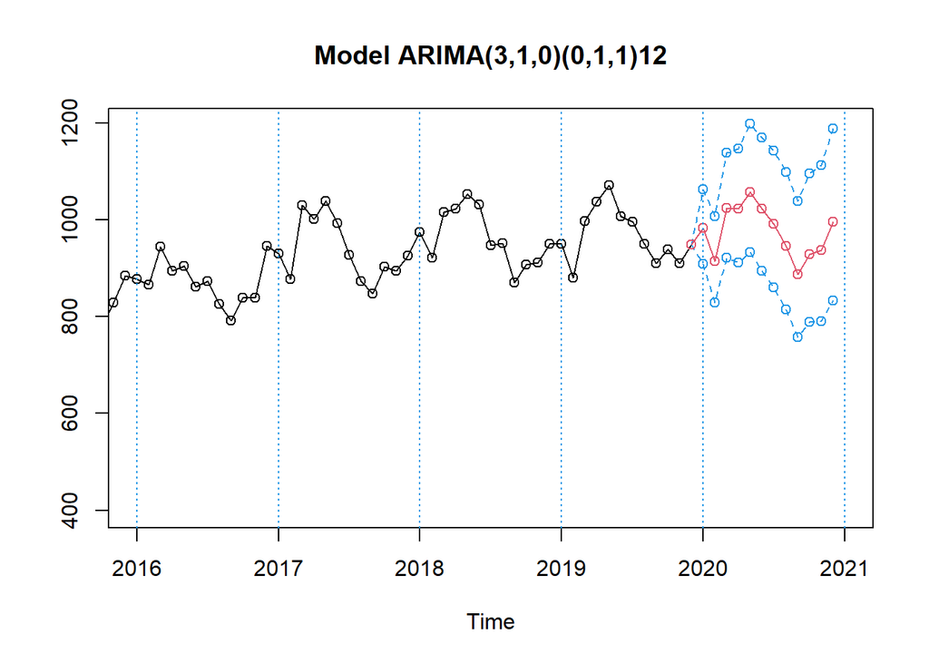

```r
pred=predict(modA,n.ahead=12)
pr<-ts(c(tail(lnserie1,1),pred$pred),start=ultim+c(1,0),freq=12)
se<-ts(c(0,pred$se),start=ultim+c(1,0),freq=12)

tl1<-ts(exp(pr-1.96*se),start=ultim+c(1,0),freq=12)
tu1<-ts(exp(pr+1.96*se),start=ultim+c(1,0),freq=12)
pr1<-ts(exp(pr),start=ultim+c(1,0),freq=12)

ts.plot(serie,tl1,tu1,pr1,lty=c(1,2,2,1),col=c(1,4,4,2),xlim=c(ultim[1]-2,ultim[1]+3),type="o",main=paste("Model ARIMA(",paste(pdq,collapse=","),")(",paste(PDQ,collapse=","),")12",sep=""))
abline(v=(ultim[1]-2):(ultim[1]+3),lty=3,col=4)
```

```r
(previs1=window(cbind(tl1,pr1,tu1),start=ultim+c(1,0)))
```

```
##               tl1       pr1      tu1
## Dec 2019 948.9920  948.9920  948.992
## Jan 2020 908.5050  982.2506 1061.982
## Feb 2020 828.9798  913.7986 1007.296
## Mar 2020 920.9431 1023.7587 1138.053
## Apr 2020 911.4797 1021.9953 1145.911
## May 2020 932.8905 1056.8515 1197.284
## Jun 2020 894.3326 1022.6818 1169.451
## Jul 2020 859.9803  991.4180 1142.944
## Aug 2020 813.8822  945.5079 1098.421
## Sep 2020 757.5029  886.6130 1037.729
## Oct 2020 788.1025  929.0435 1095.190
## Nov 2020 789.9290  937.5524 1112.764
## Dec 2020 832.6554  994.7440 1188.385
```

# Outlier Treatment

## Calendar effects

Because we have a monthly series, we check the significance of the potential calendar effects on our log_transformed series, which will be Easter and Trading Days over our model `mod1b`

```r
source("CalendarEffects.r")
data=c(start(lnserie)[1],start(lnserie)[2], length(lnserie))

(wTradDays=Wtrad(data))
```

```
##       Jan  Feb  Mar  Apr  May  Jun  Jul  Aug  Sep  Oct  Nov  Dec
## 1990  3.0  0.0 -0.5 -1.5  3.0 -1.5 -0.5  3.0 -5.0  3.0  2.0 -4.0
## 1991  3.0  0.0 -4.0  2.0  3.0 -5.0  3.0 -0.5 -1.5  3.0 -1.5 -0.5
## 1992  3.0 -2.5 -0.5  2.0 -4.0  2.0  3.0 -4.0  2.0 -0.5 -1.5  3.0
## 1993 -4.0  0.0  3.0  2.0 -4.0  2.0 -0.5 -0.5  2.0 -4.0  2.0  3.0
## 1994 -4.0  0.0  3.0 -1.5 -0.5  2.0 -4.0  3.0  2.0 -4.0  2.0 -0.5
## 1995 -0.5  0.0  3.0 -5.0  3.0  2.0 -4.0  3.0 -1.5 -0.5  2.0 -4.0
## 1996  3.0  1.0 -4.0  2.0  3.0 -5.0  3.0 -0.5 -1.5  3.0 -1.5 -0.5
## 1997  3.0  0.0 -4.0  2.0 -0.5 -1.5  3.0 -4.0  2.0  3.0 -5.0  3.0
## 1998 -0.5  0.0 -0.5  2.0 -4.0  2.0  3.0 -4.0  2.0 -0.5 -1.5  3.0
## 1999 -4.0  0.0  3.0  2.0 -4.0  2.0 -0.5 -0.5  2.0 -4.0  2.0  3.0
## 2000 -4.0  1.0  3.0 -5.0  3.0  2.0 -4.0  3.0 -1.5 -0.5  2.0 -4.0
## 2001  3.0  0.0 -0.5 -1.5  3.0 -1.5 -0.5  3.0 -5.0  3.0  2.0 -4.0
## 2002  3.0  0.0 -4.0  2.0  3.0 -5.0  3.0 -0.5 -1.5  3.0 -1.5 -0.5
## 2003  3.0  0.0 -4.0  2.0 -0.5 -1.5  3.0 -4.0  2.0  3.0 -5.0  3.0
```

[output cut: 16 more lines]

```r
(wEast=Weaster(data))
```

```
##             Jan        Feb        Mar        Apr        May        Jun
## 1990  0.0000000  0.0000000 -0.5000000  0.5000000  0.0000000  0.0000000
## 1991  0.0000000  0.0000000  0.5000000 -0.5000000  0.0000000  0.0000000
## 1992  0.0000000  0.0000000 -0.5000000  0.5000000  0.0000000  0.0000000
## 1993  0.0000000  0.0000000 -0.5000000  0.5000000  0.0000000  0.0000000
## 1994  0.0000000  0.0000000  0.1666667 -0.1666667  0.0000000  0.0000000
## 1995  0.0000000  0.0000000 -0.5000000  0.5000000  0.0000000  0.0000000
## 1996  0.0000000  0.0000000 -0.5000000  0.5000000  0.0000000  0.0000000
## 1997  0.0000000  0.0000000  0.5000000 -0.5000000  0.0000000  0.0000000
## 1998  0.0000000  0.0000000 -0.5000000  0.5000000  0.0000000  0.0000000
## 1999  0.0000000  0.0000000  0.0000000  0.0000000  0.0000000  0.0000000
## 2000  0.0000000  0.0000000 -0.5000000  0.5000000  0.0000000  0.0000000
## 2001  0.0000000  0.0000000 -0.5000000  0.5000000  0.0000000  0.0000000
## 2002  0.0000000  0.0000000  0.5000000 -0.5000000  0.0000000  0.0000000
## 2003  0.0000000  0.0000000 -0.5000000  0.5000000  0.0000000  0.0000000
```

[output cut: 47 more lines]

```r
(mod1b)
```

```
##
## Call:
## arima(x = lnserie, order = c(3, 1, 0), seasonal = list(order = c(0, 1, 1), period = 12))
##
## Coefficients:
##           ar1      ar2      ar3     sma1
##       -0.2531  -0.2808  -0.0982  -0.8163
## s.e.   0.0550   0.0541   0.0542   0.0445
##
## sigma^2 estimated as 0.001586:  log likelihood = 619.46,  aic = -1228.93
```

```r
(mod1a_TD <- arima(lnserie, order=c(3,1,0), seasonal=list(order=c(0,1,1), period=12),xreg=wTradDays))
```

```
##
## Call:
## arima(x = lnserie, order = c(3, 1, 0), seasonal = list(order = c(0, 1, 1), period = 12),
##     xreg = wTradDays)
##
## Coefficients:
##           ar1      ar2      ar3     sma1  wTradDays
##       -0.2486  -0.2826  -0.1022  -0.8148      6e-04
## s.e.   0.0550   0.0540   0.0542   0.0448      5e-04
##
## sigma^2 estimated as 0.001579:  log likelihood = 620.23,  aic = -1228.45
```

```r
(mod1a_E <- arima(lnserie, order=c(3,1,0), seasonal=list(order=c(0,1,1), period=12),xreg=wEast))
```

```
##
## Call:
## arima(x = lnserie, order = c(3, 1, 0), seasonal = list(order = c(0, 1, 1), period = 12),
##     xreg = wEast)
##
## Coefficients:
##           ar1      ar2      ar3     sma1    wEast
##       -0.2526  -0.2787  -0.1011  -0.8166  -0.0050
## s.e.   0.0550   0.0542   0.0544   0.0447   0.0071
##
## sigma^2 estimated as 0.001583:  log likelihood = 619.71,  aic = -1227.42
```

```r
(mod1a_ETD <- arima(lnserie, order=c(3,1,0), seasonal=list(order=c(0,1,1), period=12), xreg=data.frame(wTradDays,wEast)))
```

```
##
## Call:
## arima(x = lnserie, order = c(3, 1, 0), seasonal = list(order = c(0, 1, 1), period = 12),
##     xreg = data.frame(wTradDays, wEast))
##
## Coefficients:
##           ar1      ar2      ar3     sma1  wTradDays    wEast
##       -0.2483  -0.2808  -0.1043  -0.8151      6e-04  -0.0043
## s.e.   0.0550   0.0541   0.0544   0.0450      5e-04   0.0070
##
## sigma^2 estimated as 0.001577:  log likelihood = 620.41,  aic = -1226.82
```

We can observe no significance of any of the new coefficients based on calendar effects, each one has t_ratio < 2 and their inclusion doesn’t return any improvement whatsoever in the AIC. In other terms, the calendar effects are determined to be NOT significant in this time series.

## Outliers automatic detection and its treatment

```r
##Detection of outliers: In this case, we have applied a regular and a seasonal differentiation of order $S=12$. We set the criterion to $crit = 2.8$ and also the argument LS to TRUE.
## The crit value chosen by the researcher is typically fixed around 3; the LS argument is optional (= TRUE if one aims to detect a level shift)

#Our final model from the previous part was modA, which now will be called for simplicity mod
mod = modA

source("atipics2.r")

mod.atip=outdetec(mod,dif=c(1,12),crit=2.8,LS=T) # automatic detection of outliers with crit=2.8 and LS =TRUE

#Estimated residual variance after outliers detection and treatment
mod.atip$sigma
```

```
## [1] 0.001006418
```

```r
atipics=mod.atip$atip[order(mod.atip$atip[,1]),]
meses=c("Ene","Feb","Mar","Abr","May","Jun","Jul","Ago","Sep","Oct","Nov","Dic")

data.frame(atipics,Fecha=paste(meses[(atipics[,1]-1)%%12+1],start(lnserie)[1]+((atipics[,1]-1)%/%12)),perc.Obs=exp(atipics[,3])*100)
```

```
##    Obs type_detected     W_coeff ABS_L_Ratio    Fecha  perc.Obs
## 2   14            TC -0.12143268    3.605008 Feb 1991  88.56507
## 6   26            LS -0.10148992    3.217123 Feb 1992  90.34903
## 5   30            LS  0.10795333    3.373852 Jun 1992 111.39958
## 15  55            AO  0.07175605    3.003829 Jul 1994 107.43932
## 10  66            LS  0.08928625    2.983874 Jun 1995 109.33936
## 4   94            AO  0.09194066    3.334972 Oct 1997 109.62998
## 14 102            AO -0.07155394    2.958501 Jun 1998  93.09461
## 3  107            AO -0.09480214    3.386837 Nov 1998  90.95529
## 7  118            LS -0.10106559    3.250298 Oct 1999  90.38737
## 12 122            TC  0.08686853    2.960139 Feb 2000 109.07533
## 1  133            LS -0.12185740    3.571496 Ene 2001  88.52746
## 9  148            LS  0.08919276    2.944431 Abr 2002 109.32914
## 13 193            TC  0.08541710    2.944916 Ene 2006 108.91713
## 8  205            AO  0.08398489    3.228712 Ene 2007 108.76125
## 11 290            AO -0.07580495    3.005356 Feb 2014  92.69970
```

Interpretation of some of the outliers found:

- The 14th observation is identified as a transient change (TC) outlier, characterized by a notable statistical value |3.6|>2. In the logarithmic scale (our series being log-transformed), its magnitude is represented by Wcoeff=-0.12, indicating a decline in the total production of renewable energy in USA compared to what would have occurred without this atypical event. The impact of the TC outlier is evident in February 1991 during the Iraq War but diminishes relatively swiftly over subsequent periods, following an exponential decrease with a delta value of 0.7.
- On January 2001, a level shift (LS) outlier with -0.12 W_coeff is found, which means that from that point on the renewable production was lower than expected. After researching, the Department of Energy (DOE) of the US attributed much of the decline to a drought that cut generation of hydroelectric power by 23 percent, but as we can see that outlier is of type LS and not a circumstantial issue, which contradicts the DOE’s version.
- From June 1992 on, the renewable energy production raised a 10% (level shift outlier). On October of that year, the Energy Policy Act of 1992 (EPAct 1992) provided three types of incentives to support the development of renewable energy resources. Although the law approval and the trend don’t coincide in the month, we believe it could be the cause.

### Obtaining linearized time series and visualizing it

We can see below on red the linealized time series and in black the original time series.

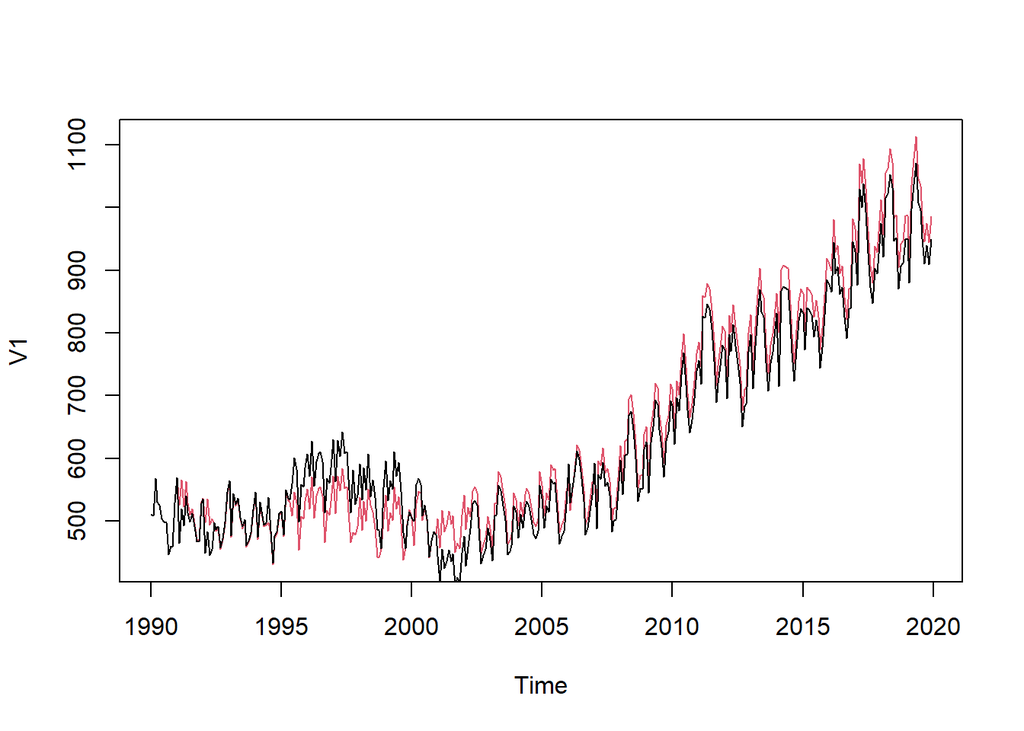

```r
lnserie.lin=lineal(lnserie,mod.atip$atip)
serie.lin=exp(lnserie.lin)

plot(serie.lin,col=2)
lines(serie)
```

### Profile of outliers effect: plot of the outliers effect in the log-transformed series

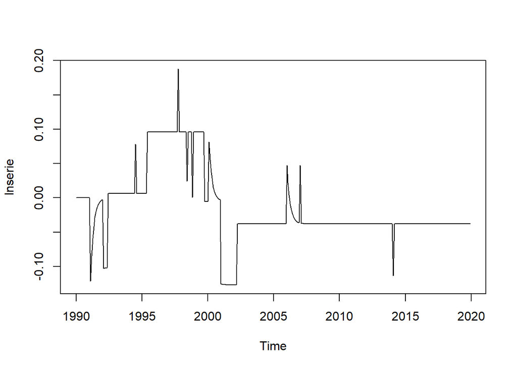

```r
plot(lnserie-lnserie.lin)
```

## Identification and Estimation based on the Linearized Series

We apply a regular difference and a seasonal difference (12 months) and we can propose a model for the linearized version:

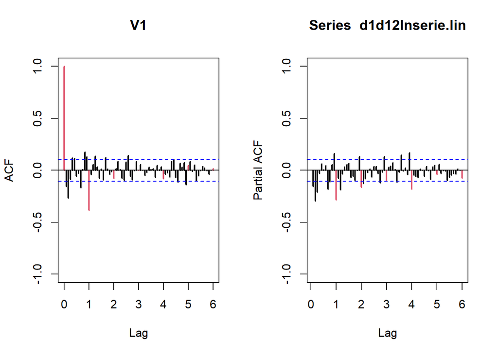

```r
d1d12lnserie.lin=diff(diff(lnserie.lin,12))
par(mfrow=c(1,2))
acf(d1d12lnserie.lin,ylim=c(-1,1),lag.max=72,col=c(2,rep(1,11)),lwd=2)
pacf(d1d12lnserie.lin,ylim=c(-1,1),lag.max=72,col=c(rep(1,11),2),lwd=2)
```

```r
par(mfrow=c(1,1))
```

- Seasonal part (red lags): SMA(Q=1) pretty clearly.
  - (0,1,1)_12 (SMA(Q=1))
- Regular part (black lags): MA(q=2) or AR(p=3). Since AR(p=3) has 3 parameters we can try with ARMA(1,1) as well.
  - (0,1,2) (MA(q=2))
  - (3,1,0) (AR(p=3))
  - (1,1,1) (ARMA(p=1,q=1))

### Final 3 proposed models:

- (0,1,2)(0,1,1)_12
- (3,1,0)(0,1,1)_12
- (1,1,1)(0,1,1)_12

```r
(mod.lin.a=arima(lnserie.lin,order=c(0,1,2),seasonal=list(order=c(0,1,1),period=12)))
```

```
##
## Call:
## arima(x = lnserie.lin, order = c(0, 1, 2), seasonal = list(order = c(0, 1, 1),
##     period = 12))
##
## Coefficients:
##           ma1      ma2     sma1
##       -0.2878  -0.2933  -0.7714
## s.e.   0.0522   0.0542   0.0454
##
## sigma^2 estimated as 0.001078:  log likelihood = 687.4,  aic = -1366.8
```

```r
abs(mod.lin.a$coef/sqrt(diag(mod.lin.a$var.coef)))
```

```
##       ma1       ma2      sma1
##  5.511183  5.414877 16.985964
```

```r
cat("\nSignificant?:",abs(mod.lin.a$coef/sqrt(diag(mod.lin.a$var.coef)))>2)
```

```
##
## Significant?: TRUE TRUE TRUE
```

```r
(mod.lin.b=arima(lnserie.lin,order=c(3,1,0),seasonal=list(order=c(0,1,1),period=12)))
```

```
##
## Call:
## arima(x = lnserie.lin, order = c(3, 1, 0), seasonal = list(order = c(0, 1, 1),
##     period = 12))
##
## Coefficients:
##           ar1      ar2      ar3     sma1
##       -0.2688  -0.3314  -0.1677  -0.7477
## s.e.   0.0547   0.0530   0.0536   0.0477
##
## sigma^2 estimated as 0.001086:  log likelihood = 686.68,  aic = -1363.37
```

```r
abs(mod.lin.b$coef/sqrt(diag(mod.lin.b$var.coef)))
```

```
##       ar1       ar2       ar3      sma1
##  4.917995  6.250569  3.132469 15.679547
```

```r
cat("\nSignificant?:",abs(mod.lin.b$coef/sqrt(diag(mod.lin.b$var.coef)))>2)
```

```
##
## Significant?: TRUE TRUE TRUE TRUE
```

```r
(mod.lin.c=arima(lnserie.lin,order=c(1,1,1),seasonal=list(order=c(0,1,1),period=12)))
```

```
##
## Call:
## arima(x = lnserie.lin, order = c(1, 1, 1), seasonal = list(order = c(0, 1, 1),
##     period = 12))
##
## Coefficients:
##          ar1      ma1     sma1
##       0.4967  -0.8259  -0.7707
## s.e.  0.0846   0.0555   0.0452
##
## sigma^2 estimated as 0.001094:  log likelihood = 684.82,  aic = -1361.65
```

```r
abs(mod.lin.c$coef/sqrt(diag(mod.lin.c$var.coef)))
```

```
##       ar1       ma1      sma1
##  5.872902 14.875022 17.036030
```

```r
cat("\nSignificant?:",abs(mod.lin.c$coef/sqrt(diag(mod.lin.c$var.coef)))>2)
```

```
##
## Significant?: TRUE TRUE TRUE
```

We see that as in the non-linearized case, the best models according to the AIC indicator are A = (0,1,2)(0,1,1)_12 and B = (3,1,0)(0,1,1)_12. Before, the validation process made us decide in favour of model B though having slightly worse AIC but slightly better results after the residual analysis. Because the AIC differences are still small here, we will decide to use `mod.lin.b` for validation and forecasting comparison to its rival `mod1b`

```r
(mod.lin.b_2=arima(lnserie.lin,order=c(4,1,0),seasonal=list(order=c(0,1,1),period=12)))
```

```
##
## Call:
## arima(x = lnserie.lin, order = c(4, 1, 0), seasonal = list(order = c(0, 1, 1),
##     period = 12))
##
## Coefficients:
##           ar1      ar2      ar3      ar4     sma1
##       -0.2764  -0.3498  -0.1837  -0.0593  -0.7549
## s.e.   0.0552   0.0556   0.0555   0.0549   0.0484
##
## sigma^2 estimated as 0.001082:  log likelihood = 687.27,  aic = -1362.53
```

```r
abs(mod.lin.b$coef/sqrt(diag(mod.lin.b$var.coef)))
```

```
##       ar1       ar2       ar3      sma1
##  4.917995  6.250569  3.132469 15.679547
```

```r
cat("\nSignificant?:",abs(mod.lin.b$coef/sqrt(diag(mod.lin.b$var.coef)))>2)
```

```
##
## Significant?: TRUE TRUE TRUE TRUE
```

```r
(mod.lin.b_3=arima(lnserie.lin,order=c(3,1,0),seasonal=list(order=c(0,1,2),period=12)))
```

```
##
## Call:
## arima(x = lnserie.lin, order = c(3, 1, 0), seasonal = list(order = c(0, 1, 2),
##     period = 12))
##
## Coefficients:
##           ar1      ar2      ar3     sma1     sma2
##       -0.2465  -0.3251  -0.1836  -0.6629  -0.1407
## s.e.   0.0551   0.0527   0.0537   0.0562   0.0594
##
## sigma^2 estimated as 0.001064:  log likelihood = 689.52,  aic = -1367.04
```

```r
abs(mod.lin.b$coef/sqrt(diag(mod.lin.b$var.coef)))
```

```
##       ar1       ar2       ar3      sma1
##  4.917995  6.250569  3.132469 15.679547
```

```r
cat("\nSignificant?:",abs(mod.lin.b$coef/sqrt(diag(mod.lin.b$var.coef)))>2)
```

```
##
## Significant?: TRUE TRUE TRUE TRUE
```

```r
(mod.lin.b_4=arima(lnserie.lin,order=c(4,1,0),seasonal=list(order=c(0,1,2),period=12)))
```

```
##
## Call:
## arima(x = lnserie.lin, order = c(4, 1, 0), seasonal = list(order = c(0, 1, 2),
##     period = 12))
##
## Coefficients:
##           ar1      ar2      ar3      ar4     sma1     sma2
##       -0.2550  -0.3441  -0.1998  -0.0640  -0.6702  -0.1424
## s.e.   0.0555   0.0551   0.0554   0.0551   0.0564   0.0591
##
## sigma^2 estimated as 0.001058:  log likelihood = 690.19,  aic = -1366.38
```

```r
abs(mod.lin.b$coef/sqrt(diag(mod.lin.b$var.coef)))
```

```
##       ar1       ar2       ar3      sma1
##  4.917995  6.250569  3.132469 15.679547
```

```r
cat("\nSignificant?:",abs(mod.lin.b$coef/sqrt(diag(mod.lin.b$var.coef)))>2)
```

```
##
## Significant?: TRUE TRUE TRUE TRUE
```

And now, according to those results, adding an extra seasonal lag `sma2`, as in `model.lin.b_3` = B = (3,1,0)(0,1,2)_12 decreases the AIC with aic = -1367.04, improving the model rating. Because of that, we finally continue with `model.lin.b_3`.

## Validation of model fitted to the (log) linearized series

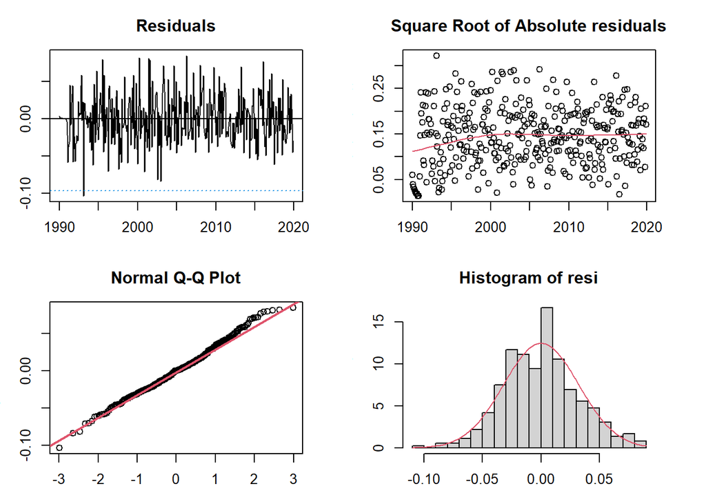

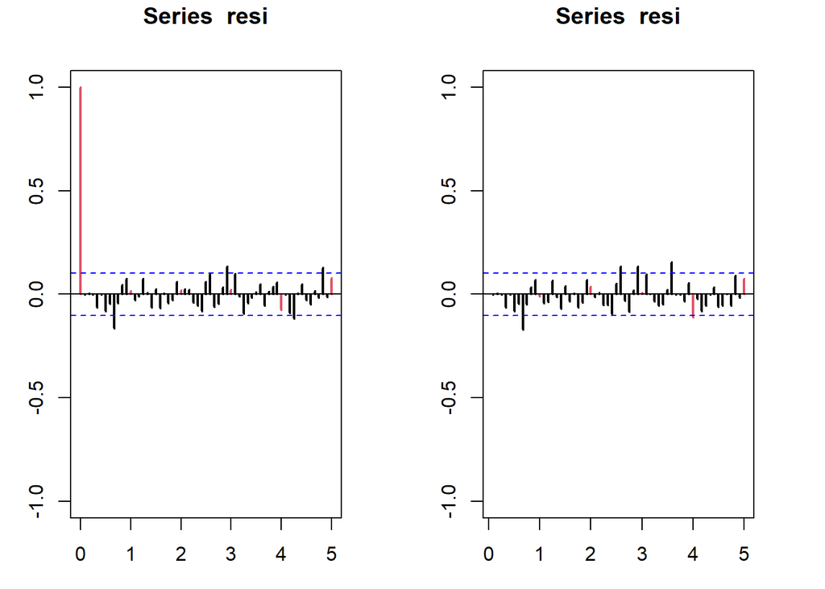

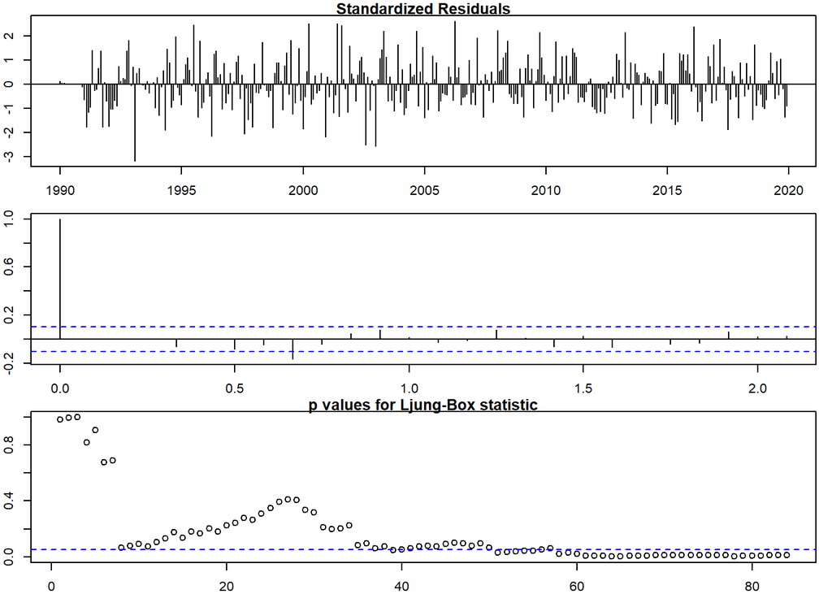

```
##
## --------------------------------------------------------------------
##
## Call:
## arima(x = lnserie.lin, order = c(3, 1, 0), seasonal = list(order = c(0, 1, 2),
##     period = 12))
##
## Coefficients:
##           ar1      ar2      ar3     sma1     sma2
##       -0.2465  -0.3251  -0.1836  -0.6629  -0.1407
## s.e.   0.0551   0.0527   0.0537   0.0562   0.0594
##
## sigma^2 estimated as 0.001064:  log likelihood = 689.52,  aic = -1367.04
##
## Modul of AR Characteristic polynomial Roots:  1.555798 2.249925 1.555798
##
## Modul of MA Characteristic polynomial Roots:  1.159602 1.015442 1.015442 1.015442 1.015442 1.015442 1.015442 1.015442 1.015442 1.159602 1.015442 1.159602 1.015442 1.015442 1.159602 1.015442 1.159602 1.159602 1.159602 1.159602 1.159602 1.159602 1.159602 1.159602
```

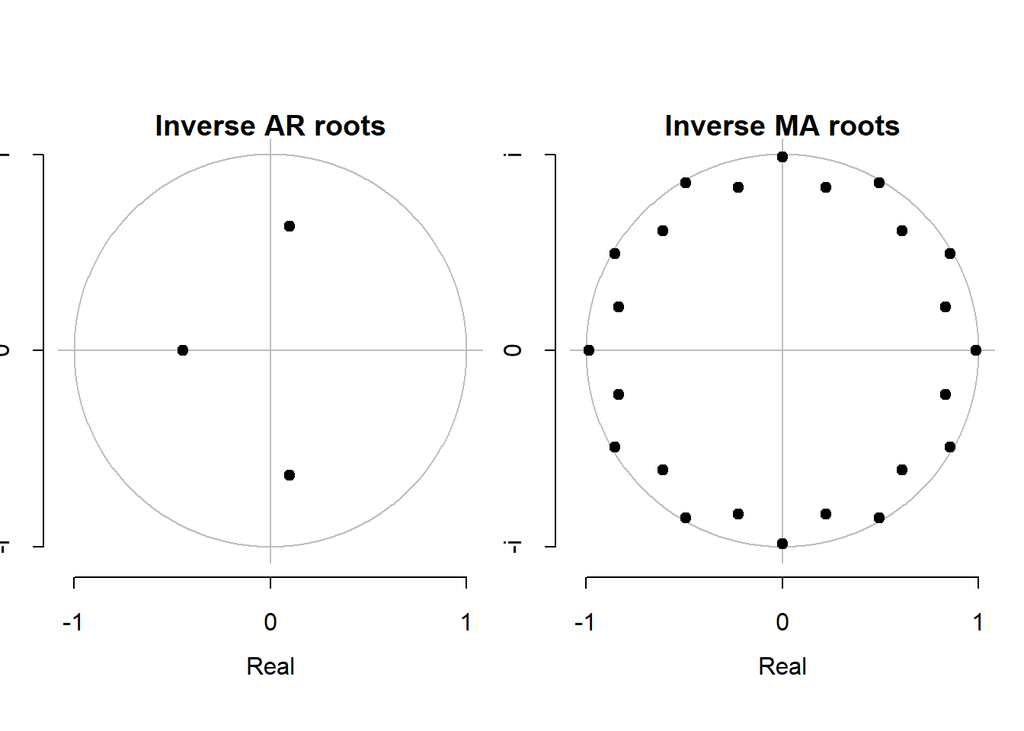

```
##
## Psi-weights (MA(inf))
##
## --------------------
##        psi 1        psi 2        psi 3        psi 4        psi 5        psi 6
## -0.246480152 -0.264390644 -0.038314087  0.140667749  0.026333813 -0.045192585
##        psi 7        psi 8        psi 9       psi 10       psi 11       psi 12
## -0.023252940  0.015589966  0.012016289 -0.003760985 -0.005842674 -0.662415830
##       psi 13       psi 14       psi 15       psi 16       psi 17       psi 18
##  0.165862661  0.175570935  0.024430570 -0.093563440 -0.017120667  0.030155411
##       psi 19       psi 20       psi 21       psi 22       psi 23       psi 24
##  0.015314305 -0.010435757 -0.007944344  0.002539187  0.003873429 -0.141066225
##
## Pi-weights (AR(inf))
##
## --------------------
##       pi 1       pi 2       pi 3       pi 4       pi 5       pi 6       pi 7
## -0.2464802 -0.3251431 -0.1836225  0.0000000  0.0000000  0.0000000  0.0000000
##       pi 8       pi 9      pi 10      pi 11      pi 12      pi 13      pi 14
##  0.0000000  0.0000000  0.0000000  0.0000000 -0.6628723 -0.1633849 -0.2155284
##      pi 15      pi 16      pi 17      pi 18      pi 19      pi 20      pi 21
## -0.1217182  0.0000000  0.0000000  0.0000000  0.0000000  0.0000000  0.0000000
##      pi 22      pi 23      pi 24
##  0.0000000  0.0000000 -0.5801444
##
## Descriptive Statistics for the Residuals
##
## ----------------------------------------
##                   resi
## nobs        360.000000
## NAs           0.000000
## Minimum      -0.103594
## Maximum       0.085027
## 1. Quartile  -0.022359
## 3. Quartile   0.018912
## Mean          0.000016
## Median        0.000376
## Sum           0.005813
## SE Mean       0.001691
## LCL Mean     -0.003310
```

[output cut: 44 more lines]

```
## data:  resi ~ I(1:length(resi))
## DW = 2.0016, p-value = 0.485
## alternative hypothesis: true autocorrelation is greater than 0
##
##
## Ljung-Box test
##      lag.df    statistic    p.value
## [1,]      1 5.162561e-04 0.98187261
## [2,]      2 7.410514e-03 0.99630160
## [3,]      3 7.621676e-03 0.99982344
## [4,]      4 1.541184e+00 0.81932200
## [5,]     12 1.842311e+01 0.10343435
## [6,]     24 2.690603e+01 0.30885231
## [7,]     36 4.731384e+01 0.09825655
## [8,]     48 6.239681e+01 0.07921868
```

```r
model=mod.lin.b_3       #Fitted ARIMA model: in this case mod is ARIMA(0,1,2)(0,1,1)_12 for lnserie
validation(model)
```

**Normality and variance**

**Invertibility and causality**

Modul of AR Characteristic polynomial Roots: 1.555798 2.249925 1.555798 Modul of MA Characteristic polynomial Roots: 1.159602 1.015442 1.015442 1.015442 1.015442 1.015442 1.015442 1.015442 1.015442 1.159602 1.015442 1.159602 1.015442 1.015442 1.159602 1.015442 1.159602 1.159602 1.159602 1.159602 1.159602 1.159602 1.159602 1.159602

Yes to both, all roots >1 in both cases for AR(inf) and MA(inf).

**Residuals independence**

We have to arrive until lag 50 in the Ljung-Box test in order to fail lag independence, which is a considerable improvement compared to previous models. On the other hand, in the Durbin-Watson test the accepted hypothesis is that there is no evidence to suggest a first-order autocorrelation in the residuals, and they can be considered independent.

#### Linearized model stability

```r
ultim=c(2018,12)
pdq=c(3,1,0)
PDQ=c(0,1,2)

serie1.lin=window(serie.lin,end=ultim+c(1,0))
lnserie1.lin=log(serie1.lin)
serie2.lin=window(serie.lin,end=ultim)
lnserie2.lin=log(serie2.lin)

(mod.lin=arima(lnserie1.lin,order=pdq,seasonal=list(order=PDQ,period=12)))
```

```
##
## Call:
## arima(x = lnserie1.lin, order = pdq, seasonal = list(order = PDQ, period = 12))
##
## Coefficients:
##           ar1      ar2      ar3     sma1     sma2
##       -0.2465  -0.3251  -0.1836  -0.6629  -0.1407
## s.e.   0.0551   0.0527   0.0537   0.0562   0.0594
##
## sigma^2 estimated as 0.001064:  log likelihood = 689.52,  aic = -1367.04
```

```r
(mod2.lin=arima(lnserie2.lin,order=pdq,seasonal=list(order=PDQ,period=12)))
```

```
##
## Call:
## arima(x = lnserie2.lin, order = pdq, seasonal = list(order = PDQ, period = 12))
##
## Coefficients:
##           ar1      ar2      ar3     sma1     sma2
##       -0.2521  -0.3270  -0.1827  -0.6564  -0.1476
## s.e.   0.0563   0.0536   0.0544   0.0574   0.0623
##
## sigma^2 estimated as 0.001075:  log likelihood = 663.77,  aic = -1315.53
```

Because of the huge similarity in the coefficients and standard error we confirm the stability of the linearized model.

## Forecasting and prediction capability: linearized model

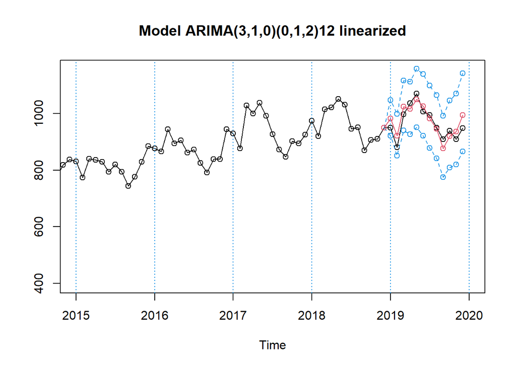

```r
pred=predict(mod2.lin,n.ahead=12)
wLS=sum(mod.atip$atip[mod.atip$atip$type_detected=="LS" & mod.atip$atip$Obs<=length(serie)-12,3])
predic=pred$pr+wLS
pr<-ts(c(tail(lnserie2,1),predic),start=ultim,freq=12) #puntual predictions (log-scale) obtained
se<-ts(c(0,pred$se),start=ultim,freq=12) #Standard errors for puntual predictions

##Prediction Intervals (back transformed to original scale using exp-function)
tl<-ts(exp(pr-1.96*se),start=ultim,freq=12)
tu<-ts(exp(pr+1.96*se),start=ultim,freq=12)
pr<-ts(exp(pr),start=ultim,freq=12)

#Plot of the original airbcn series (thousands) and out-of-sample predictions
ts.plot(serie,tl,tu,pr,lty=c(1,2,2,1),col=c(1,4,4,2),xlim=ultim[1]+c(-3,+2),type="o",main="Model ARIMA(3,1,0)(0,1,2)12 linearized")
abline(v=(ultim[1]-3):(ultim[1]+2),lty=3,col=4)
```

```r
mCI2=mean(tu-tl)

cat("\nMean Length CI: ",mCI2)
```

```
##
## Mean Length CI:  191.2267
```

```r
(previs.lin=window(cbind(tl,pr,tu,serie,error=round(serie-pr,3)),start=ultim))
```

```
##                tl        pr        tu    serie   error
## Dec 2018 949.7590  949.7590  949.7590  949.759   0.000
## Jan 2019 921.1222  982.2626 1047.4614  949.921 -32.342
## Feb 2019 851.0405  922.1527  999.2069  880.451 -41.702
## Mar 2019 939.9565 1024.4516 1116.5422  997.161 -27.291
## Apr 2019 927.7135 1015.9119 1112.4953 1037.089  21.177
## May 2019 951.3795 1049.8075 1158.4187 1071.009  21.201
## Jun 2019 922.2914 1025.5138 1140.2888 1007.147 -18.367
## Jul 2019 878.0430  982.3168 1098.9739  995.467  13.150
## Aug 2019 841.5703  946.5948 1064.7260  949.779   3.184
## Sep 2019 775.7311  877.3068  992.1830  909.946  32.639
## Oct 2019 809.3389  920.2970 1046.4672  938.857  18.560
## Nov 2019 819.3510  936.4772 1070.3465  909.319 -27.158
## Dec 2019 866.2095  994.8455 1142.5846  948.992 -45.854
```

```r
obs=window(serie,start=ultim)
mod.RMSE2=sqrt(sum((obs-pr)^2)/12)
mod.MAE2=sum(abs(obs-pr))/12
mod.RMSPE2=sqrt(sum(((obs-pr)/obs)^2)/12)
mod.MAPE2=sum(abs(obs-pr)/obs)/12

data.frame("RMSE"=mod.RMSE2,"MAE"=mod.MAE2,"RMSPE"=mod.RMSPE2,"MAPE"=mod.MAPE2)
```

```
##       RMSE      MAE      RMSPE       MAPE
## 1 27.68585 25.21872 0.02941481 0.02646803
```

#### Long term prediction linearized model

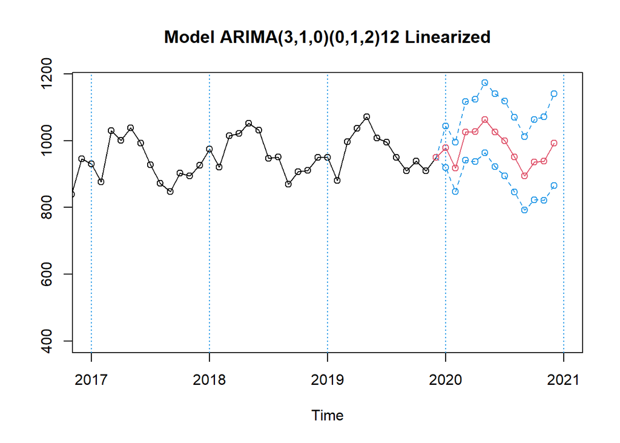

```r
pred=predict(mod.lin,n.ahead=12)
wLS=sum(mod.atip$atip[mod.atip$atip$type_detected=="LS",3])

##Must correct predictions for LS outliers
predic=pred$pr+wLS

pr<-ts(c(lnserie[length(lnserie)],predic),start=ultim+c(1,0),freq=12)
se<-ts(c(0,pred$se),start=ultim+c(1,0),freq=12)

#Intervals
tl2<-ts(exp(pr-1.96*se),start=ultim+c(1,0),freq=12)
tu2<-ts(exp(pr+1.96*se),start=ultim+c(1,0),freq=12)
pr2<-ts(exp(pr),start=ultim+c(1,0),freq=12)

ts.plot(serie,tl2,tu2,pr2,lty=c(1,2,2,1),col=c(1,4,4,2),xlim=ultim[1]+c(-1,+3),type="o",main="Model ARIMA(3,1,0)(0,1,2)12 Linearized")
abline(v=(ultim[1]-2):(ultim[1]+3),lty=3,col=4)
```

## Compare the original and linearized model

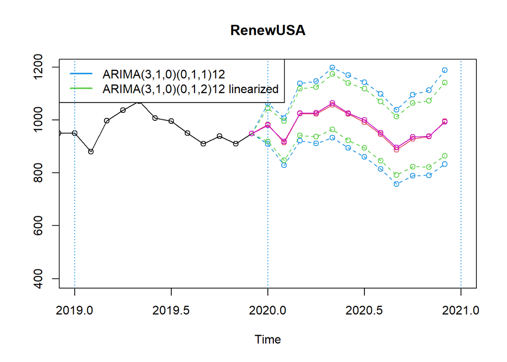

```r
ts.plot(serie,tl1,tu1,pr1,tl2,tu2,pr2,lty=c(1,2,2,1,2,2,1),col=c(1,4,4,2,3,3,6),xlim=ultim[1]+c(1,3),type="o",main="RenewUSA")
legend("topleft",c("ARIMA(3,1,0)(0,1,1)12","ARIMA(3,1,0)(0,1,2)12 linearized"),col=c(4,3),lty=1,lwd=2)
abline(v=ultim[1]+1:3,lty=3,col=4)
```

As we can observe, the predictions between the two models are very similar. The only difference lies in the confidence band, which has been reduced for the linearized model, which is a bit more assertive about its predictions.

```r
resul=data.frame(
  par=c(length(coef(mod)),length(coef(mod.lin))+nrow(mod.atip$atip)),
  Sigma2Z=c(mod$sigma2,mod.lin$sigma2),
  AIC=c(AIC(mod),AIC(mod.lin)+2*nrow(mod.atip$atip)),
  BIC=c(BIC(mod),BIC(mod.lin)+log(length(serie)-13)*nrow(mod.atip$atip)),
  RMSE=c(mod.RMSE1,mod.RMSE2),
  MAE=c(mod.MAE1,mod.MAE2),
  RMSPE=c(mod.RMSPE1,mod.RMSPE2),
  MAPE=c(mod.MAPE1,mod.MAPE2),
  meanLength=c(mCI1,mCI2))
row.names(resul)=c("ARIMA(3,1,0)(0,1,1)_12","ARIMA(3,1,0)(0,1,2)_12 Linearized")
resul
```

```
##                                   par     Sigma2Z       AIC       BIC     RMSE
## ARIMA(3,1,0)(0,1,1)_12              4 0.001585584 -1228.926 -1209.680 27.05704
## ARIMA(3,1,0)(0,1,2)_12 Linearized  20 0.001064148 -1337.038 -1256.203 27.68585
##                                        MAE      RMSPE       MAPE meanLength
## ARIMA(3,1,0)(0,1,1)_12            25.20676 0.02845077 0.02633460   242.4543
## ARIMA(3,1,0)(0,1,2)_12 Linearized 25.21872 0.02941481 0.02646803   191.2267
```

The linearized model is a better model according to AIC and BIC, but in this 2019 to 2020 prediction, the evaluation metrics (RMSE, MAE, RMSPE, MAPE) tell us that the non-linearized model gives slightly better values. For instance the RMSE of the ARIMA(3,1,0)(0,1,1)_12 is 27.05704, whilst for the ARIMA(3,1,0)(0,1,2)_12 Linearized is 27.68585, which is 0.6 points worse approximately.